# Dongshan_sand_example

Anyi Hu

2019/11/17

##Introduction An example for analyzing the amplicon sequencing data

Data sources: 2017_Dongshan_Sand_Microbiome_16S amplicon sequencing dataset

Copyright: Dr. Anyi Hu (ayhu@iue.ac.cn)

Citation: Anyi Hu*, Hongjie Wang, Meixian Cao, Azhar Rashid, Mingfeng Li, Chang-Ping Yu. Environmental filtering drives the assembly of habitat generalists and specialists in the coastal sand microbial communities of southern China. Microorganisms. Under review ##

Some References for make the R codes below:

1. Schmidt, M.L., White, J.D. and Denef, V.J. (2016) Phylogenetic conservation of freshwater lake habitat preference varies between abundant bacterioplankton phyla. Environ. Microbiol. 18(4), 1212-1226.
2. Burns, A.R., Stephens, W.Z., Stagaman, K., Wong, S., Rawls, J.F., Guillemin, K. and Bohannan, B.J. (2016) Contribution of neutral processes to the assembly of gut microbial communities in the zebrafish over host development. ISME J. 10(3), 655-664.
3. Tucker, C.M., Shoemaker, L.G., Davies, K.F., Nemergut, D.R. and Melbourne, B.A. (2016) Differentiating between niche and neutral assembly in metacommunities using null models of β-diversity. Oikos 125(6), 778-789.
4. Wu, W., Logares, R., Huang, B. and Hsieh, C.H. (2017) Abundant and rare picoeukaryotic sub-communities present contrasting patterns in the epipelagic waters of marginal seas in the northwestern Pacific Ocean. Environ. Microbiol. 19(1), 287-300.
5. Sokol, E.R., Herbold, C.W., Lee, C.K., Cary, S.C. and Barrett, J.E. (2013) Local and regional influences over soil microbial metacommunities in the Transantarctic Mountains. Ecosphere 4(11), art136.
6. Hou, L.; Hu, A.; Chen, S.; Zhang, K.; Orlic, S.; Rashid, A.; Yu, C.P. Deciphering the Assembly Processes of the Key Ecological Assemblages of Microbial Communities in Thirteen Full-Scale Wastewater Treatment Plants. Microbes. Environ. 2019, 34, 169-179.

## Loading data

```r
##########################################################################################################
###Loading Data file
##########################################################################################################
load("Dongshang_example.RData")

##########################################################################################################
###Manipulate the phyloseq dataset
##########################################################################################################
##Remove the singletons
dongshan_sand.nonsing <- prune_taxa(taxa_sums(dongshan_sand1) > 1, dongshan_sand1)
min(sample_sums(dongshan_sand.nonsing))
```

```
## [1] 19920
```

```r
##Sub-sampling to equal sequening efforts
dongshan_sand2 = rarefy_even_depth(dongshan_sand.nonsing, rngseed = 12345,
                                   sample.size = 19000,
                                   replace = F)

any(taxa_sums(dongshan_sand2) == 0)
```

```
## [1] FALSE
```

```r
any(sample_sums(dongshan_sand2) == 0)
```

```
## [1] FALSE
```

```r
any(taxa_sums(dongshan_sand2) == 0)
```

```
## [1] FALSE
```

```r
any(sample_sums(dongshan_sand2) == 0)
```

```
## [1] FALSE
```

```r
rank_names(dongshan_sand2)
```

```
## [1] "Kingdom" "Phylum"  "Class"   "Order"   "Family"  "Genus"
```

```r
sample_variables(dongshan_sand2)
```

```
##  [1] "X.SampleID"           "LinkerPrimerSequence" "ReversePrimer"
##  [4] "Original.ID"          "Site"                 "Site1"
##  [7] "Environment"          "Location"             "Grain.size"
## [10] "EC"                   "TN"                   "NH4.N"
## [13] "NO2.N"                "NO3.N"                "Available.P"
## [16] "TOC"                  "Cd"                   "Pb"
## [19] "Hg"                   "Cr"                   "As"
## [22] "Ni"                   "Cu"                   "Zn"
```

```r
head(sample_data(dongshan_sand2))
```

```
##            X.SampleID LinkerPrimerSequence        ReversePrimer
## DS2017j11j DS2017j11j   GTGYCAGCMGCCGCGGTA CCGYCAATTYMTTTRAGTTT
## DS2017j11s DS2017j11s   GTGYCAGCMGCCGCGGTA CCGYCAATTYMTTTRAGTTT
## DS2017j12j DS2017j12j   GTGYCAGCMGCCGCGGTA CCGYCAATTYMTTTRAGTTT
## DS2017j12s DS2017j12s   GTGYCAGCMGCCGCGGTA CCGYCAATTYMTTTRAGTTT
## DS2017j13j DS2017j13j   GTGYCAGCMGCCGCGGTA CCGYCAATTYMTTTRAGTTT
## DS2017j13s DS2017j13s   GTGYCAGCMGCCGCGGTA CCGYCAATTYMTTTRAGTTT
##            Original.ID Site Site1      Environment    Location Grain.size
## DS2017j11j        J11J  JL1 JL1_i intertidal sands Jinluan Bay    484.245
## DS2017j11s        J11S  JL1 JL1_b  backshore sands Jinluan Bay    269.302
## DS2017j12j        J12J  JL1 JL1_i intertidal sands Jinluan Bay    448.309
## DS2017j12s        J12S  JL1 JL1_b  backshore sands Jinluan Bay    264.966
## DS2017j13j        J13J  JL1 JL1_i intertidal sands Jinluan Bay    319.838
## DS2017j13s        J13S  JL1 JL1_b  backshore sands Jinluan Bay    346.444
##                EC  TN NH4.N NO2.N NO3.N Available.P  TOC   Cd  Pb    Hg Cr
## DS2017j11j 2620.0 285  3.20  0.30  1.23        12.7 0.16   na 5.8    na 52
## DS2017j11s   57.6 197  4.15  0.69  1.21        12.2 0.22 0.02 6.8 0.006 22
## DS2017j12j 1910.0 190  1.06  0.20  0.69        14.8 0.24 0.02 5.2 0.006 53
## DS2017j12s   89.7 215  2.57  0.39  1.06        13.0 0.07 0.01 6.5 0.006 11
## DS2017j13j 1870.0 109  3.13  0.39  1.26        13.1 0.14   na 4.8    na 60
## DS2017j13s   93.4 153  2.64  0.59  1.18        11.4 0.14   na 6.2 0.006 13
##              As Ni Cu   Zn
## DS2017j11j 3.19  6  4 10.9
## DS2017j11s 3.83 na  2 11.8
## DS2017j12j 2.64  6  2 11.9
## DS2017j12s 3.92 na  2 10.4
## DS2017j13j 3.43  6  2 11.5
## DS2017j13s 3.12 na  2 11.8
```

## Fig.2

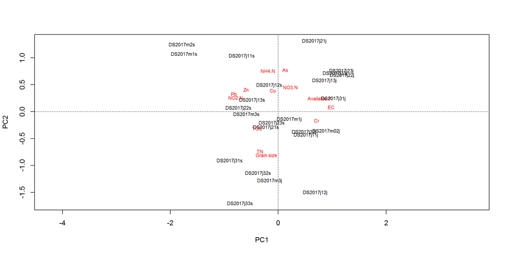

```r
##########################################################################################################
###PCA analysis of Environmental variables--------------Fig.2
##########################################################################################################
sand2017_env = as(sample_data(dongshan_sand.nonsing), "data.frame")
sand2017_env1 = sand2017_env[,c(9:16,18,20,21,23,24)]

sand2017_env2 <- data.frame(sapply(sand2017_env1, function(x) as.numeric(as.character(x))))
rownames(sand2017_env2) = row.names(sand2017_env)

##
pca_env = rda(sand2017_env2, scale = TRUE, na.action = na.exclude)
plot(pca_env, type = "t")
```

```r
##Extract PCA scores
data.scores <- as.data.frame(scores(pca_env, choices = 1:2)$sites)  #Using the scores function from vegan to extract the site scores and tranform into data.frame
data.scores$site1 <- sand2017_env$Site1  # create a column of site names, from the rownames of data.scores
data.scores$site <- sand2017_env$Site
data.scores$Environment <- sand2017_env$Environment
head(data.scores)  #look at the data
```

```
##                   PC1        PC2 site1 site      Environment
## DS2017j11j  0.5112976 -0.4353508 JL1_i  JL1 intertidal sands
## DS2017j11s -0.6779364  1.0353260 JL1_b  JL1  backshore sands
## DS2017j12j  0.6826045 -1.5039506 JL1_i  JL1 intertidal sands
## DS2017j12s -0.1670419  0.4915866 JL1_b  JL1  backshore sands
## DS2017j13j  0.8527856  0.5778940 JL1_i  JL1 intertidal sands
## DS2017j13s -0.4861885  0.2159650 JL1_b  JL1  backshore sands
```

```r
species.scores <- as.data.frame(scores(pca_env, choices = 1:2)$species)  #Using the scores function from vegan to extract the species scores and convert to a data.frame
species.scores$species <- rownames(species.scores)  # create a column of species, from the rownames of species.scores
head(species.scores)  #look at the data
```

```
##                   PC1         PC2    species
## Grain.size -0.2175317 -0.80720958 Grain.size
## EC          0.9805036  0.08416332         EC
## TN         -0.3419536 -0.73696160         TN
## NH4.N      -0.1943267  0.75673286      NH4.N
## NO2.N      -0.7869320  0.26003308      NO2.N
## NO3.N       0.2272992  0.45389641      NO3.N
```

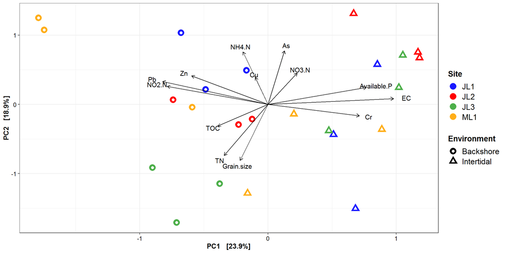

```r
##Define the arrow aesthetic mapping
pca_arrow_map <- aes(xend = PC1, yend = PC2, x = 0, y = 0,
                     shape = NULL, color = NULL,
                     label = species)

pca_label_map <- aes(x = 1.1 * PC1, y = 1.1 * PC2,
                     shape = NULL, color = NULL,
                     label = species)

pca_arrowhead = arrow(length = unit(0.015, "npc"))

##Plot
pca_plot = plot_ordination(physeq = dongshan_sand.nonsing, ordination = pca_env,
                           color = "Site", axes = c(1,2)) +
  aes(color = Site, shape = Environment) +
  geom_point(aes(colour = Site), alpha = 1, size = 5) +
  geom_point(colour = "white", size = 2) +
  scale_color_manual(name = "Site", values = c("#1919ff","red", "#4daf4a", "#ffae19",
                                               "#a65628", "darkorchid3", "magenta")) +
  scale_shape_manual(values=c(19, 17),
                     breaks = c("backshore sands", "intertidal sands"),
                     labels= c("Backshore", "Intertidal")) +
  theme_bw() +
  theme(axis.title.x = element_text(face="bold", size=12),
        axis.title.y = element_text(face="bold", size=12),
        axis.text.x = element_text(colour = "black", size=10),
        axis.text.y = element_text(colour = "black", size=10),
        legend.title = element_text(size=13.5, face = "bold"),
        legend.text = element_text(size=13.5),
        legend.position="right")

##Plot
pca_plot2 = pca_plot +
  geom_segment(mapping = pca_arrow_map,
               size = 0.5, data = species.scores,
               color = "black", arrow = pca_arrowhead) +
  geom_text(mapping = pca_label_map,
            size = 4, data = species.scores,
            show.legend = FALSE)

pca_plot2
```

## Fig. S1

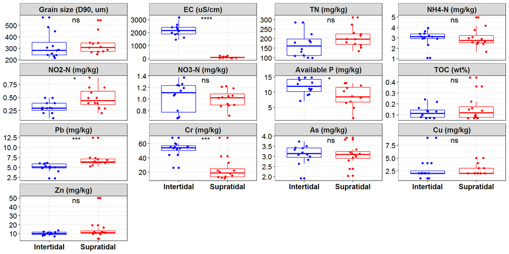

```r
########################################################################################################
####Boxplot of Environmental varibales--------------Fig.S1
#########################################################################################################
sand2017_env3 = sand2017_env2 #Creat a duplicate ENV data.frame
sand2017_env3$Environment <- sand2017_env$Environment

##Reshape the data
sum_sand2017_env <- gather(sand2017_env3, "Env_factors", "Value",
                           Grain.size,  EC, TN, NH4.N, NO2.N,
                           NO3.N, Available.P, TOC, Pb, Cr,
                           As, Cu, Zn)

##Change Env_factors
sum_sand2017_env$Env_factors <- as.character(sum_sand2017_env$Env_factors)
sum_sand2017_env$Env_factors[sum_sand2017_env$Env_factors == "Available.P"] <- "Available P (mg/kg)"
sum_sand2017_env$Env_factors[sum_sand2017_env$Env_factors == "Grain.size"] <- "Grain size (D90, um)"
sum_sand2017_env$Env_factors[sum_sand2017_env$Env_factors == "NH4.N"] <- "NH4-N (mg/kg)"
sum_sand2017_env$Env_factors[sum_sand2017_env$Env_factors == "NO2.N"] <- "NO2-N (mg/kg)"
sum_sand2017_env$Env_factors[sum_sand2017_env$Env_factors == "NO3.N"] <- "NO3-N (mg/kg)"
sum_sand2017_env$Env_factors[sum_sand2017_env$Env_factors == "EC"] <- "EC (uS/cm)"
sum_sand2017_env$Env_factors[sum_sand2017_env$Env_factors == "TN"] <- "TN (mg/kg)"
sum_sand2017_env$Env_factors[sum_sand2017_env$Env_factors == "TOC"] <- "TOC (wt%)"
sum_sand2017_env$Env_factors[sum_sand2017_env$Env_factors == "Pb"] <- "Pb (mg/kg)"
sum_sand2017_env$Env_factors[sum_sand2017_env$Env_factors == "Cr"] <- "Cr (mg/kg)"
sum_sand2017_env$Env_factors[sum_sand2017_env$Env_factors == "As"] <- "As (mg/kg)"
sum_sand2017_env$Env_factors[sum_sand2017_env$Env_factors == "Cu"] <- "Cu (mg/kg)"
sum_sand2017_env$Env_factors[sum_sand2017_env$Env_factors == "Zn"] <- "Zn (mg/kg)"

##Change other factors
sum_sand2017_env$Environment <- as.character(sum_sand2017_env$Environment)
sum_sand2017_env$Environment[sum_sand2017_env$Environment == "backshore sands"] <- "Supratidal"
sum_sand2017_env$Environment[sum_sand2017_env$Environment == "intertidal sands"] <- "Intertidal"

##set factor
sum_sand2017_env$Env_factors <-factor(sum_sand2017_env$Env_factors,
                                      levels=c("Grain size (D90, um)", "EC (uS/cm)", "TN (mg/kg)",
                                               "NH4-N (mg/kg)", "NO2-N (mg/kg)", "NO3-N (mg/kg)",
                                               "Available P (mg/kg)",  "TOC (wt%)", "Pb (mg/kg)",
                                               "Cr (mg/kg)", "As (mg/kg)", "Cu (mg/kg)",
                                               "Zn (mg/kg)"))



##Plot
p_box_env1 = ggboxplot(sum_sand2017_env, x = "Environment", y = "Value",
          color = "Environment", palette = c("blue", "red"),
          add = "jitter",
          facet.by = "Env_factors", scales = "free_y",
          short.panel.labs = T) +
  stat_compare_means(label =  "p.signif", label.x = 1.5, label.y.npc = 0.95,
                     size = 4.5) +
  theme_bw() +
  theme(axis.title.x = element_blank(),
        axis.text.x = element_text(colour = "black", size=12.5, face = "bold"),
        axis.text.y = element_text(colour = "black", size=12),
        axis.title.y = element_blank(),
        plot.title = element_text(face="bold", size = 12, hjust = 0.5),
        legend.title = element_text(size=10, face="bold"),
        legend.text = element_text(size = 10),
        strip.text = element_text(size = 12.5, face = "bold"),
        legend.position="none")

p_box_env1
```

```r
######################################################################################################
####Identifying Habitat generalists and specialists
######################################################################################################
##Generating an OTU table
otu_sand = as.data.frame(otu_table(dongshan_sand2))

set.seed(124358)
##partitoning the microbial communities into habitat generalists and specialists
#sand_perm <- spec.gen(otu_sand,niche.width.method="levins",perm.method="quasiswap",
#                      n=1000,probs=c(0.025,0.975))  ##take too long time to run, so pend it

length(grep('GENERALIST',sand_perm$sign)) #No. of generalists
```

```
## [1] 774
```

```r
length(grep('NON',sand_perm$sign)) #No. of others
```

```
## [1] 8942
```

```r
length(grep('SPECIALIST',sand_perm$sign)) #No. of specialists
```

```
## [1] 144
```

```r
dim(sand_perm)
```

```
## [1] 9860    5
```

```r
##
sand_generalist <- row.names(subset(sand_perm, sign == "GENERALIST"))
sand_specialist <- row.names(subset(sand_perm, sign == "SPECIALIST"))

##
sand_qiime_generalist = prune_taxa(sand_generalist, dongshan_sand2)
any(taxa_sums(sand_qiime_generalist) == 0)
```

```
## [1] FALSE
```

```r
any(sample_sums(sand_qiime_generalist) == 0)
```

```
## [1] FALSE
```

```r
otu_sand_generalist = as.data.frame(t(otu_table(sand_qiime_generalist)))

sand_qiime_specialist = prune_taxa(sand_specialist, dongshan_sand2)
any(taxa_sums(sand_qiime_specialist) == 0)
```

```
## [1] FALSE
```

```r
any(sample_sums(sand_qiime_specialist) == 0)
```

```
## [1] FALSE
```

```r
otu_sand_specialist = as.data.frame(t(otu_table(sand_qiime_specialist)))
```

## Table 1

```r
####################################################################################################
###beta-diversity analysis--------------Table 1 and Fig. 3
#############################################################################################################
############################Adonis and ANOSIM analysis
##Whole
dist.whole = phyloseq::distance(dongshan_sand2, "bray")
sand2017_env = as(sample_data(dongshan_sand2), "data.frame")

adonis(dist.whole ~ Site*Environment, data = sand2017_env, perm = 9999)
```

```
##
## Call:
## adonis(formula = dist.whole ~ Site * Environment, data = sand2017_env,      permutations = 9999)
##
## Permutation: free
## Number of permutations: 9999
##
## Terms added sequentially (first to last)
##
##                  Df SumsOfSqs MeanSqs F.Model      R2 Pr(>F)
## Site              3    1.5922 0.53074  3.1203 0.20028 0.0003 ***
## Environment       1    2.0882 2.08821 12.2769 0.26267 0.0001 ***
## Site:Environment  3    1.5482 0.51605  3.0339 0.19473 0.0002 ***
## Residuals        16    2.7215 0.17009         0.34232
## Total            23    7.9501                 1.00000
## ---
## Signif. codes:  0 '***' 0.001 '**' 0.01 '*' 0.05 '.' 0.1 ' ' 1
```

```r
attach(sand2017_env)
anosim(dist.whole, Environment, perm = 9999)
```

```
##
## Call:
## anosim(x = dist.whole, grouping = Environment, permutations = 9999)
## Dissimilarity: bray
##
## ANOSIM statistic R: 0.6689
##       Significance: 0.0001
##
## Permutation: free
## Number of permutations: 9999
```

```r
anosim(dist.whole, Site, perm = 9999)
```

```
##
## Call:
## anosim(x = dist.whole, grouping = Site, permutations = 9999)
## Dissimilarity: bray
##
## ANOSIM statistic R: 0.1305
##       Significance: 0.0669
##
## Permutation: free
## Number of permutations: 9999
```

```r
###For gen
dist.gen = phyloseq::distance(sand_qiime_generalist, "bray")

adonis(dist.gen ~ Environment*Site, data = sand2017_env, perm = 9999)
```

```
##
## Call:
## adonis(formula = dist.gen ~ Environment * Site, data = sand2017_env,      permutations = 9999)
##
## Permutation: free
## Number of permutations: 9999
##
## Terms added sequentially (first to last)
##
##                  Df SumsOfSqs MeanSqs F.Model      R2 Pr(>F)
## Environment       1    2.1032 2.10315 20.3616 0.33655 0.0001 ***
## Site              3    1.2784 0.42614  4.1256 0.20457 0.0007 ***
## Environment:Site  3    1.2150 0.40501  3.9211 0.19443 0.0004 ***
## Residuals        16    1.6526 0.10329         0.26446
## Total            23    6.2492                 1.00000
## ---
## Signif. codes:  0 '***' 0.001 '**' 0.01 '*' 0.05 '.' 0.1 ' ' 1
```

```r
attach(sand2017_env)
anosim(dist.gen, Environment, perm = 9999)
```

```
##
## Call:
## anosim(x = dist.gen, grouping = Environment, permutations = 9999)
## Dissimilarity: bray
##
## ANOSIM statistic R: 0.6405
##       Significance: 0.0003
##
## Permutation: free
## Number of permutations: 9999
```

```r
anosim(dist.gen, Site, perm = 9999)
```

```
##
## Call:
## anosim(x = dist.gen, grouping = Site, permutations = 9999)
## Dissimilarity: bray
##
## ANOSIM statistic R: 0.1369
##       Significance: 0.0564
##
## Permutation: free
## Number of permutations: 9999
```

```r
###For spe
dist.spe = phyloseq::distance(sand_qiime_specialist, "bray")

adonis(dist.spe ~ Site*Environment, data = sand2017_env, perm = 9999)
```

```
##
## Call:
## adonis(formula = dist.spe ~ Site * Environment, data = sand2017_env,      permutations = 9999)
##
## Permutation: free
## Number of permutations: 9999
##
## Terms added sequentially (first to last)
##
##                  Df SumsOfSqs MeanSqs F.Model      R2 Pr(>F)
## Site              3    1.5637 0.52125  2.4754 0.17786 0.0004 ***
## Environment       1    2.0742 2.07425  9.8506 0.23592 0.0001 ***
## Site:Environment  3    1.7850 0.59500  2.8256 0.20302 0.0001 ***
## Residuals        16    3.3691 0.21057         0.38320
## Total            23    8.7921                 1.00000
## ---
## Signif. codes:  0 '***' 0.001 '**' 0.01 '*' 0.05 '.' 0.1 ' ' 1
```

```r
anosim(dist.spe, Environment, perm = 9999)
```

```
##
## Call:
## anosim(x = dist.spe, grouping = Environment, permutations = 9999)
## Dissimilarity: bray
##
## ANOSIM statistic R: 0.6855
##       Significance: 0.0001
##
## Permutation: free
## Number of permutations: 9999
```

```r
anosim(dist.spe, Site, perm = 9999)
```

```
##
## Call:
## anosim(x = dist.spe, grouping = Site, permutations = 9999)
## Dissimilarity: bray
##
## ANOSIM statistic R: 0.06219
##       Significance: 0.1742
##
## Permutation: free
## Number of permutations: 9999
```

## Fig. 3

```r
######################################################################################################
##########################################NMDS oridination
##NMDS plot for the whole communities
sand_nmds.bray <- ordinate(physeq = dongshan_sand2, method = "NMDS", distance = "bray")
```

```
## Square root transformation
## Wisconsin double standardization
## *** No convergence -- monoMDS stopping criteria:
##     20: stress ratio > sratmax
```

```r
##Plot
p_nmds = plot_ordination(physeq = dongshan_sand2, ordination = sand_nmds.bray,
                         color = "Site", shape = "Environment") +
  scale_color_manual(name = "Site", values = c("#1919ff","red", "#4daf4a", "#ffae19",
                                               "#a65628", "darkorchid3", "magenta")) +
  geom_point(aes(colour = Site), alpha = 0.7, size = 4.5) +
  geom_point(colour = "white", size = 1.5) +
  theme_bw() +
  theme(axis.title.x = element_text(face="bold", size=12),
        axis.title.y = element_text(face="bold", size=12),
        axis.text.x = element_text(colour = "black", size=10),
        axis.text.y = element_text(colour = "black", size=10),
        legend.position="none")


##NMDS plot for the generalists
sand_gen_nmds <- ordinate(physeq = sand_qiime_generalist, method = "NMDS", distance = "bray")
```

```
## Square root transformation
## Wisconsin double standardization
## *** No convergence -- monoMDS stopping criteria:
##     20: stress ratio > sratmax
```

```r
##Plot
p_nmds_gen = plot_ordination(physeq = sand_qiime_generalist, ordination = sand_gen_nmds,
                             color = "Site", shape = "Environment") +
  scale_color_manual(name = "Location", values = c("#1919ff","red", "#4daf4a", "#ffae19",
                                                   "#a65628", "darkorchid3", "magenta")) +
  geom_point(aes(colour = Site), alpha = 0.7, size = 4.5) +
  geom_point(colour = "white", size = 1.5) +
  theme_bw() +
  theme(axis.title.x = element_text(face="bold", size=12),
        axis.title.y = element_text(face="bold", size=12),
        axis.text.x = element_text(colour = "black", size=10),
        axis.text.y = element_text(colour = "black", size=10),
        legend.position="none")


##NMDS plot for the specialists
sand_spe_nmds <- ordinate(physeq = sand_qiime_specialist, method = "NMDS", distance = "bray")
```

```
## Square root transformation
## Wisconsin double standardization
## *** Solution reached
```

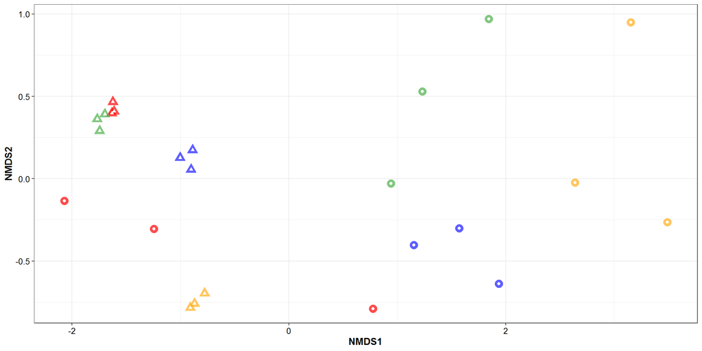

```r
##Plot
p_nmds_spe = plot_ordination(physeq = sand_qiime_specialist, ordination = sand_spe_nmds,
                             color = "Site", shape = "Environment") +
  geom_point(aes(colour = Site), alpha = 0.7, size = 4.5) +
  geom_point(colour = "white", size = 1.2) +
  scale_color_manual(name = "Site", values = c("#1919ff","red", "#4daf4a", "#ffae19",
                                               "#a65628", "darkorchid3", "magenta")) +
  scale_shape_manual(values=c(19, 17),
                     breaks = c("backshore sands", "intertidal sands"),
                     labels= c("Supratidal", "Intertidal")) +
  theme_bw() +
  theme(axis.title.x = element_text(face="bold", size=12),
        axis.title.y = element_text(face="bold", size=12),
        axis.text.x = element_text(colour = "black", size=10),
        axis.text.y = element_text(colour = "black", size=10),
        legend.title = element_text(size=13.5, face = "bold"),
        legend.text = element_text(size=13.5),
        legend.position="right")

p_nmds
```

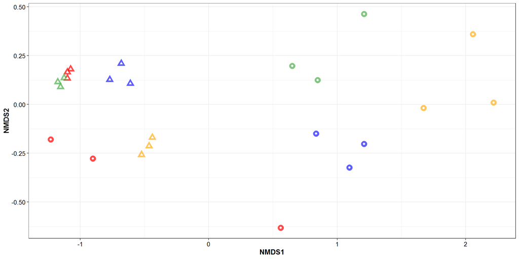

```r
p_nmds_gen
```

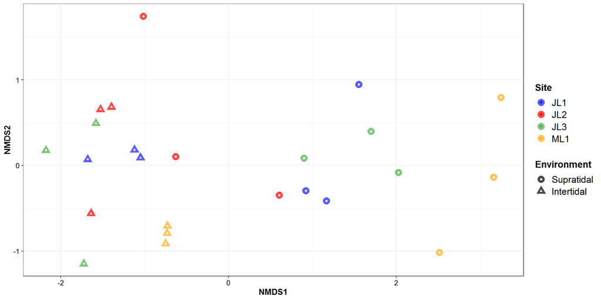

```r
p_nmds_spe
```

## Fig. 4

```r
######################################################################################################
###Taxonomic assignment analysis--------------Fig.4
######################################################################################################
##Whole communities
phy <- data.frame(tax_table(dongshan_sand.nonsing))
Phylum <- as.character(phy$Phylum)
Class <- as.character(phy$Class)
Order <- as.character(phy$Order)
sum(is.na(phy))
```

```
## [1] 13646
```

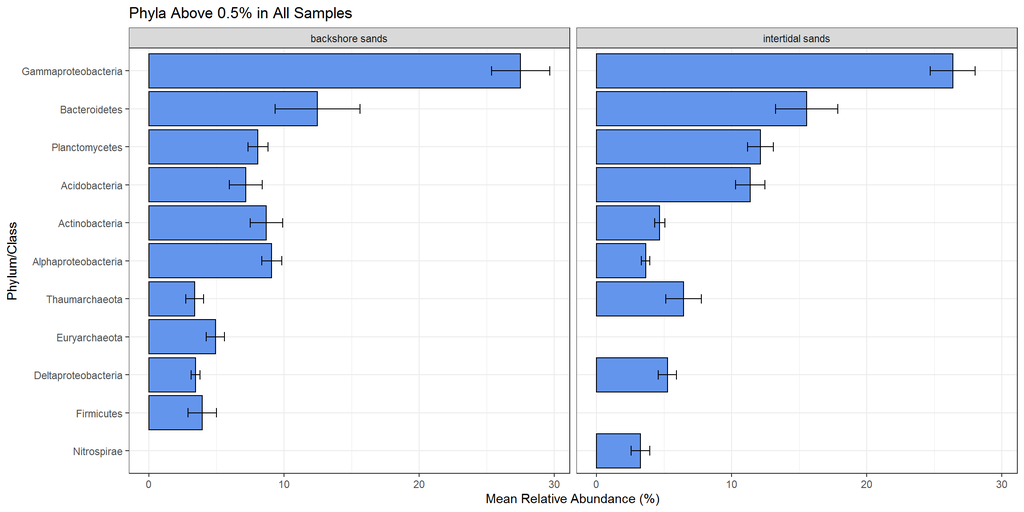

```r
#complete.cases(phy)
#phy[which(phy=="NA")]

##Add the Alphaproteobacteria to the Phyla
for (i in 1:length(Phylum)){
  if(!is.na(Phylum[i])){
    if (Phylum[i] == "Proteobacteria")
      Phylum[i] <- Class[i]}
}

##
phy$Phylum <- Phylum
t <- tax_table(as.matrix(phy))

tax_table(dongshan_sand.nonsing) <- t


##The phyloseq object!
dongshan_sand.nonsing1 <- prune_taxa(taxa_sums(dongshan_sand.nonsing) > 0, dongshan_sand.nonsing)
good_phylum <-tax_glom(dongshan_sand.nonsing1, taxrank = "Phylum")

##Melt it into a dataframe
goodsamps_phy_melt <- psmelt(good_phylum)
sub_goodsamps_phy_melt <- subset(goodsamps_phy_melt, select = c("Sample", "Site", "Environment",
                                                                "Location", "Phylum", "Abundance"))

### Merge phylum sums and the total numbers -> so we can calculate the Relative Abundance
sums_sand2018 <- data.frame(colSums(t(otu_table(dongshan_sand.nonsing))))
colnames(sums_sand2018) <- "Sample_TotalSeqs"
sums_sand2018$Sample <- row.names(sums_sand2018)
sub_phy_melt_totals <- merge(sub_goodsamps_phy_melt, sums_sand2018, by = "Sample")
## Calculate the relative abundance
sub_phy_melt_totals$RelAbundance <- sub_phy_melt_totals$Abundance/sub_phy_melt_totals$Sample_TotalSeqs
##  Calculate the Percent Abundance
sub_phy_melt_totals$PercentAbund <- sub_phy_melt_totals$RelAbundance * 100

####  Make a new dataframe with the percent abudance within the entire dataset!
phy_stats <- ddply(sub_phy_melt_totals, c("Phylum", "Environment"), summarise,
                   N = length(PercentAbund),
                   PercentPhy = mean(PercentAbund),
                   sd   = sd(PercentAbund),
                   se   = sd / sqrt(N))

abund <- subset(phy_stats,PercentPhy > 3)  # Only take the phyla that are more than 3% abundant

##Relative abundance plot
ggplot(abund, aes(y=PercentPhy, x=reorder(Phylum, PercentPhy)))  +
  geom_bar(stat="identity", position=position_dodge(),  fill = "cornflowerblue", colour = "black") +
  facet_grid( ~Environment) +
  theme_bw() + ggtitle("Phyla Above 0.5% in All Samples") +
  xlab("Phylum/Class") + ylab("Mean Relative Abundance (%)") +
  geom_errorbar(aes(ymin = PercentPhy -se, ymax = PercentPhy +se), width = 0.25) +
  coord_flip()
```

```r
#######Generalists
gen_phy <- data.frame(tax_table(sand_qiime_generalist))
Phylum <- as.character(gen_phy$Phylum)
Class <- as.character(gen_phy$Class)
sum(is.na(gen_phy))
```

```
## [1] 968
```

```r
#complete.cases(gen_phy)
#gen_phy[which(gen_phy =="NA")]

for (i in 1:length(Phylum)){
  if(!is.na(Phylum[i])){
    if (Phylum[i] == "Proteobacteria")
      Phylum[i] <- Class[i]}
}

gen_phy$Phylum <- Phylum
t <- tax_table(as.matrix(gen_phy))

tax_table(sand_qiime_generalist) <- t

# The phyloseq object!
sand_qiime_generalist1 <- prune_taxa(taxa_sums(sand_qiime_generalist) > 0, sand_qiime_generalist)
good_gen_phylum <-tax_glom(sand_qiime_generalist1, taxrank = "Phylum")

##  Melt it into a dataframe
goodsamps_gen_phy_melt <- psmelt(good_gen_phylum)
sub_goodsamps_gen_phy_melt <- subset(goodsamps_gen_phy_melt, select = c("Sample", "Site", "Environment",
                                                                        "Location", "Phylum",
                                                                        "Abundance"))

### Merge phylum sums and the total numbers -> so we can calculate the Relative Abundance
sums_gen <- data.frame(colSums(t(otu_table(sand_qiime_generalist))))
colnames(sums_gen) <- "Sample_TotalSeqs"
sums_gen$Sample <- row.names(sums_gen)
sums_gen <- arrange(sums_gen, Sample_TotalSeqs)
TOTALS_read_gen = sum(sums_gen$Sample_TotalSeqs)
sub_gen_phy_melt_totals <- merge(sub_goodsamps_gen_phy_melt, sums_gen, by = "Sample")
## Calculate the relative abundance
sub_gen_phy_melt_totals$RelAbundance <- sub_gen_phy_melt_totals$Abundance/sub_gen_phy_melt_totals$Sample_TotalSeqs
##  Calculate the Percent Abundance
sub_gen_phy_melt_totals$PercentAbund <- sub_gen_phy_melt_totals$RelAbundance * 100

####  Make a new dataframe with the percent abudance within the entire dataset!
phy_gen_stats <- ddply(sub_gen_phy_melt_totals, c("Phylum", "Environment"), summarise,
                       N = length(PercentAbund),
                       PercentPhy = mean(PercentAbund),
                       sd   = sd(PercentAbund),
                       se   = sd / sqrt(N))

abund_gen_phy <- subset(phy_gen_stats,PercentPhy > 3)  # Only take the phyla that are more than 0.5% abundant


#######Specialists
spe_phy <- data.frame(tax_table(sand_qiime_specialist))
Phylum <- as.character(spe_phy$Phylum)
Class <- as.character(spe_phy$Class)
sum(is.na(spe_phy))
```

```
## [1] 76
```

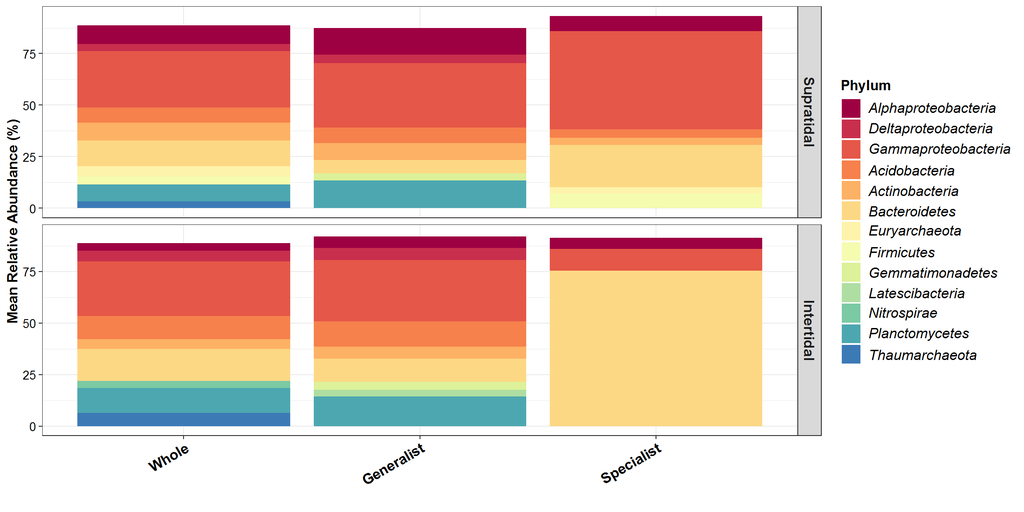

```r
#complete.cases(spe_phy)
#spe_phy[which(spe_phy =="NA")]

for (i in 1:length(Phylum)){
  if(!is.na(Phylum[i])){
    if (Phylum[i] == "Proteobacteria")
      Phylum[i] <- Class[i]}
}

spe_phy$Phylum <- Phylum
t <- tax_table(as.matrix(spe_phy))

tax_table(sand_qiime_specialist) <- t


# The phyloseq object!
sand_qiime_specialist1 <- prune_taxa(taxa_sums(sand_qiime_specialist) > 0, sand_qiime_specialist)
good_spe_phylum <-tax_glom(sand_qiime_specialist1, taxrank = "Phylum")

##  Melt it into a dataframe
goodsamps_spe_phy_melt <- psmelt(good_spe_phylum)
sub_goodsamps_spe_phy_melt <- subset(goodsamps_spe_phy_melt, select = c("Sample", "Site", "Environment",
                                                                        "Location", "Phylum",
                                                                        "Abundance"))

### Merge phylum sums and the total numbers -> so we can calculate the Relative Abundance
sums_spe <- data.frame(colSums(t(otu_table(sand_qiime_specialist))))
colnames(sums_spe) <- "Sample_TotalSeqs"
sums_spe$Sample <- row.names(sums_spe)
sums_spe <- arrange(sums_spe, Sample_TotalSeqs)
TOTALS_read_spe = sum(sums_spe$Sample_TotalSeqs)
sub_spe_phy_melt_totals <- merge(sub_goodsamps_spe_phy_melt, sums_spe, by = "Sample")
## Calculate the relative abundance
sub_spe_phy_melt_totals$RelAbundance <- sub_spe_phy_melt_totals$Abundance/sub_spe_phy_melt_totals$Sample_TotalSeqs
##  Calculate the Percent Abundance
sub_spe_phy_melt_totals$PercentAbund <- sub_spe_phy_melt_totals$RelAbundance * 100

####  Make a new dataframe with the percent abudance within the entire dataset!
phy_spe_stats <- ddply(sub_spe_phy_melt_totals, c("Phylum", "Environment"), summarise,
                       N = length(PercentAbund),
                       PercentPhy = mean(PercentAbund),
                       sd   = sd(PercentAbund),
                       se   = sd / sqrt(N))

abund_spe_phy <- subset(phy_spe_stats,PercentPhy > 3)  # Only take the phyla that are more than 3% abundant


####combine different groups for phylum plot
abund$group = paste("whole")
abund_gen_phy$group = paste("gen")
abund_spe_phy$group = paste("spe")

phy_allgroups = rbind(abund, abund_gen_phy, abund_spe_phy)
phy_allgroups$Phylum = factor(phy_allgroups$Phylum, levels = c("Alphaproteobacteria", "Deltaproteobacteria",
                                                               "Gammaproteobacteria",
                                                               "Acidobacteria", "Actinobacteria",
                                                               "Bacteroidetes",  "Euryarchaeota",
                                                               "Firmicutes",  "Gemmatimonadetes",
                                                               "Latescibacteria", "Nitrospirae",
                                                               "Planctomycetes", "Thaumarchaeota"))
phy_allgroups$group = factor(phy_allgroups$group, levels = c("whole", "gen", "spe"))

levels(phy_allgroups$Environment) <- c("Supratidal", "Intertidal")

#Plot
phy_bac_plot = ggplot(phy_allgroups, aes(x = group, y = PercentPhy, fill = Phylum))  +
  geom_bar(stat = 'identity', position = 'stack') +
  scale_fill_manual(values = c("#9E0142", "#C82F4C", "#E55748", "#F6814C", "#FDB164",
                               "#FDD884", "#FEF3AB", "#F5FBAF", "#DCF199", "#AFDEA3",
                               "#7BCAA4", "#4DA7B0", "#3C7AB6", "#5E4FA2"), name = "Phylum",
                    labels = expression(italic("Alphaproteobacteria"), italic("Deltaproteobacteria"),
                                        italic("Gammaproteobacteria"), italic("Acidobacteria"),
                                        italic("Actinobacteria"), italic( "Bacteroidetes"),
                                        italic("Euryarchaeota"), italic("Firmicutes"),
                                        italic("Gemmatimonadetes"), italic("Latescibacteria"),
                                        italic("Nitrospirae"), italic("Planctomycetes"),
                                        italic("Thaumarchaeota")))+
  scale_x_discrete(name = "",
                   breaks = c("whole", "gen", "spe"),
                   labels = c("Whole", "Generalist", "Specialist"))+
  ylab("Mean Relative Abundance (%)") +
  facet_grid(Environment ~.) +
  theme_bw() +
  theme(plot.title = element_text(hjust = 0.5, face=c("italic", "bold"), size=14),
        axis.title.x = element_text(face="bold", size=12),
        axis.title.y = element_text(face="bold", size=12),
        axis.text.x = element_text(angle=30, vjust=1, hjust=1, colour = "black", face="bold", size=12),  #Set the x-axis labels
        axis.text.y = element_text(colour = "black", size=10),
        strip.text = element_text(size = 12, face = "bold"),
        legend.title = element_text(size = 12, face="bold"),
        legend.text = element_text(size = 12),
        legend.text.align = 0)

phy_bac_plot
```

## Fig. 4B

```r
########################################################################################################
###Family level--------------Fig.4B
######################################################################################################
##Whole communities
fam <- data.frame(tax_table(dongshan_sand.nonsing))
Family <- as.character(fam$Family)
OTU <- as.character(rownames(fam))
sum(is.na(fam))
```

```
## [1] 13656
```

```r
#complete.cases(fam)
#fam[which(fam =="NA")]

fam$family <- Family
t <- tax_table(as.matrix(fam))

tax_table(dongshan_sand.nonsing) <- t


# The phyloseq object!
dongshan_sand.nonsing1 <- prune_taxa(taxa_sums(dongshan_sand.nonsing) > 0, dongshan_sand.nonsing)
good_family <-tax_glom(dongshan_sand.nonsing1, taxrank = "Family")

good_family %>%
  subset_taxa(Family !="Unknown_Family") -> good_family

##  Melt it into a dataframe
goodsamps_fam_melt <- psmelt(good_family)
sub_goodsamps_fam_melt <- subset(goodsamps_fam_melt, select = c("Sample", "Site", "Environment",
                                                                        "Location", "Family", "OTU",
                                                                        "Abundance"))

### Merge phylum sums and the total numbers -> so we can calculate the Relative Abundance
sub_fam_melt_totals <- merge(sub_goodsamps_fam_melt, sums_sand2018, by = "Sample")
## Calculate the relative abundance
sub_fam_melt_totals$RelAbundance <- sub_fam_melt_totals$Abundance/sub_fam_melt_totals$Sample_TotalSeqs
##  Calculate the Percent Abundance
sub_fam_melt_totals$PercentAbund <- sub_fam_melt_totals$RelAbundance * 100

####  Make a new dataframe with the percent abudance within the entire dataset!
fam_stats <- ddply(sub_fam_melt_totals, c("OTU","Family", "Environment"), summarise,
                       N = length(PercentAbund),
                       PercentPhy = mean(PercentAbund),
                       sd   = sd(PercentAbund),
                       se   = sd / sqrt(N))

abund_fam <- subset(fam_stats,PercentPhy > 2.2)  # Only take the phyla that are more than 2.2% abundant


##Generalists
gen_fam <- data.frame(tax_table(sand_qiime_generalist))
Family <- as.character(gen_fam$Family)
OTU <- as.character(rownames(gen_fam))
sum(is.na(gen_fam))
```

```
## [1] 968
```

```r
#complete.cases(gen_fam)
#gen_fam[which(gen_fam =="NA")]

gen_fam$family <- Family
t <- tax_table(as.matrix(gen_fam))

tax_table(sand_qiime_generalist) <- t

# The phyloseq object!
sand_qiime_generalist1 <- prune_taxa(taxa_sums(sand_qiime_generalist) > 0, sand_qiime_generalist)
good_gen_family <-tax_glom(sand_qiime_generalist1, taxrank = "Family")

good_gen_family %>%
  subset_taxa(Family !="Unknown_Family") -> good_gen_family

##  Melt it into a dataframe
goodsamps_gen_fam_melt <- psmelt(good_gen_family)
sub_goodsamps_gen_fam_melt <- subset(goodsamps_gen_fam_melt, select = c("Sample", "Site", "Environment",
                                                                "Location", "Family", "OTU",
                                                                "Abundance"))

### Merge phylum sums and the total numbers -> so we can calculate the Relative Abundance
sums_gen <- data.frame(colSums(t(otu_table(sand_qiime_generalist))))
colnames(sums_gen) <- "Sample_TotalSeqs"
sums_gen$Sample <- row.names(sums_gen)
sums_gen <- arrange(sums_gen, Sample_TotalSeqs)
TOTALS_read_gen = sum(sums_gen$Sample_TotalSeqs)
sub_gen_fam_melt_totals <- merge(sub_goodsamps_gen_fam_melt, sums_gen, by = "Sample")
## Calculate the relative abundance
sub_gen_fam_melt_totals$RelAbundance <- sub_gen_fam_melt_totals$Abundance/sub_gen_fam_melt_totals$Sample_TotalSeqs
##  Calculate the Percent Abundance
sub_gen_fam_melt_totals$PercentAbund <- sub_gen_fam_melt_totals$RelAbundance * 100

####  Make a new dataframe with the percent abudance within the entire dataset!
fam_gen_stats <- ddply(sub_gen_fam_melt_totals, c("OTU","Family", "Environment"), summarise,
                   N = length(PercentAbund),
                   PercentPhy = mean(PercentAbund),
                   sd   = sd(PercentAbund),
                   se   = sd / sqrt(N))

abund_gen_fam <- subset(fam_gen_stats,PercentPhy > 2.2)  # Only take the phyla that are more than 2.2% abundant


##Specialists
spe_fam <- data.frame(tax_table(sand_qiime_specialist))
Family <- as.character(spe_fam$Family)
OTU <- as.character(rownames(spe_fam))
sum(is.na(spe_fam))
```

```
## [1] 76
```

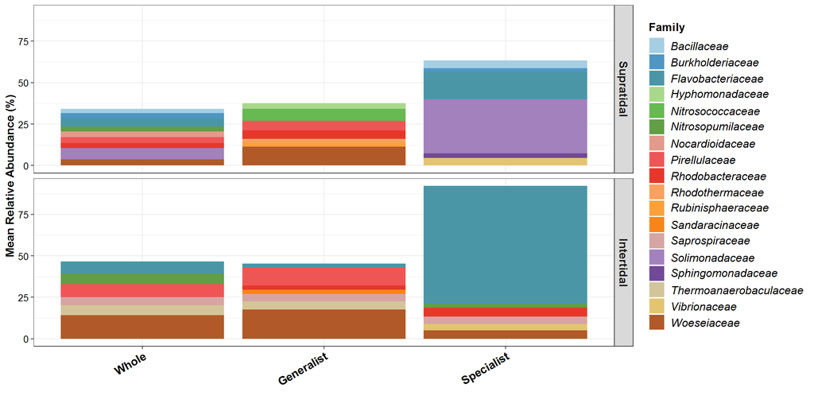

```r
#complete.cases(spe_fam)
#spe_fam[which(spe_fam =="NA")]

spe_fam$family <- Family
t <- tax_table(as.matrix(spe_fam))

tax_table(sand_qiime_specialist) <- t


# The phyloseq object!
sand_qiime_specialist1 <- prune_taxa(taxa_sums(sand_qiime_specialist) > 0, sand_qiime_specialist)
good_spe_family <-tax_glom(sand_qiime_specialist1, taxrank = "Family")

good_spe_family %>%
  subset_taxa(Family !="Unknown_Family") -> good_spe_family


##  Melt it into a dataframe
goodsamps_spe_fam_melt <- psmelt(good_spe_family)
sub_goodsamps_spe_fam_melt <- subset(goodsamps_spe_fam_melt, select = c("Sample", "Site", "Environment",
                                                                        "Location", "Family", "OTU",
                                                                        "Abundance"))

### Merge phylum sums and the total numbers -> so we can calculate the Relative Abundance
sums_spe <- data.frame(colSums(t(otu_table(sand_qiime_specialist))))
colnames(sums_spe) <- "Sample_TotalSeqs"
sums_spe$Sample <- row.names(sums_spe)
sums_spe <- arrange(sums_spe, Sample_TotalSeqs)
TOTALS_read_spe = sum(sums_spe$Sample_TotalSeqs)
sub_spe_fam_melt_totals <- merge(sub_goodsamps_spe_fam_melt, sums_spe, by = "Sample")
## Calculate the relative abundance
sub_spe_fam_melt_totals$RelAbundance <- sub_spe_fam_melt_totals$Abundance/sub_spe_fam_melt_totals$Sample_TotalSeqs
##  Calculate the Percent Abundance
sub_spe_fam_melt_totals$PercentAbund <- sub_spe_fam_melt_totals$RelAbundance * 100

####  Make a new dataframe with the percent abudance within the entire dataset!
fam_spe_stats <- ddply(sub_spe_fam_melt_totals, c("OTU","Family", "Environment"), summarise,
                       N = length(PercentAbund),
                       PercentPhy = mean(PercentAbund),
                       sd   = sd(PercentAbund),
                       se   = sd / sqrt(N))

abund_spe_fam <- subset(fam_spe_stats,PercentPhy > 2.2)  # Only take the phyla that are more than 2.2% abundant


####Combine different groups for family plot
abund_fam$group = paste("whole")
abund_gen_fam$group = paste("gen")
abund_spe_fam$group = paste("spe")

fam_allgroups = rbind(abund_fam, abund_gen_fam, abund_spe_fam)

fam_allgroups$Family = factor(fam_allgroups$Family,
                              levels = c("Bacillaceae", "Burkholderiaceae", "Flavobacteriaceae",
                                         "Hyphomonadaceae", "Nitrosococcaceae", "Nitrosopumilaceae",
                                         "Nocardioidaceae", "Pirellulaceae", "Rhodobacteraceae",
                                         "Rhodothermaceae", "Rubinisphaeraceae", "Sandaracinaceae",
                                         "Saprospiraceae", "Solimonadaceae", "Sphingomonadaceae",
                                         "Thermoanaerobaculaceae", "Vibrionaceae", "Woeseiaceae"))
fam_allgroups$group = factor(fam_allgroups$group, levels = c("whole", "gen", "spe"))

levels(fam_allgroups$Environment) <- c("Supratidal", "Intertidal")

#Plot
fam_bac_plot = ggplot(fam_allgroups, aes(x=group, y=PercentPhy, fill = Family))  +
  geom_bar(stat = 'identity', position = 'stack') +
  scale_fill_manual(values=c("#A6CEE3", "#4E96C4", "#4A96A7", "#A9D88C", "#67B952",
                             "#629E45", "#E39A8C", "#EE5656", "#E7372A", "#F8A160",
                             "#FDA03A", "#F88519", "#D6A5A3", "#A281BD", "#724899",
                             "#D3C599", "#E3C471", "#B15928"), name = "Family",
                    labels = expression(italic("Bacillaceae"), italic("Burkholderiaceae"),
                                        italic("Flavobacteriaceae"), italic("Hyphomonadaceae"),
                                        italic("Nitrosococcaceae"), italic("Nitrosopumilaceae"),
                                        italic("Nocardioidaceae"), italic("Pirellulaceae"),
                                        italic("Rhodobacteraceae"), italic("Rhodothermaceae"),
                                        italic("Rubinisphaeraceae"), italic("Sandaracinaceae"),
                                        italic("Saprospiraceae"), italic("Solimonadaceae"),
                                        italic("Sphingomonadaceae"), italic("Thermoanaerobaculaceae"),
                                        italic("Vibrionaceae"), italic("Woeseiaceae")))+
  scale_x_discrete(name = "",
                   breaks = c("whole", "gen", "spe"),
                   labels = c("Whole", "Generalist", "Specialist"))+
  ylab("Mean Relative Abundance (%)") +
  facet_grid(Environment ~.) +
  theme_bw() +
  theme(plot.title = element_text(hjust = 0.5, face=c("italic", "bold"), size=14),
        axis.title.x = element_text(face="bold", size=12),  #Set the x-axis title
        axis.title.y = element_text(face="bold", size=12),  #Set the y-axis title
        axis.text.x = element_text(angle=30, vjust=1, hjust = 1, colour = "black", face="bold", size=12),  #Set the x-axis labels
        axis.text.y = element_text(colour = "black", size=10),
        strip.text = element_text(size = 12, face = "bold"),
        legend.title = element_text(size = 12, face="bold"),
        legend.text = element_text(size = 12),
        legend.text.align = 0)

fam_bac_plot
```

```r
##################################################################################################
###Genus level
##################################################################################################
gen <- data.frame(tax_table(dongshan_sand.nonsing))
Genus <- as.character(gen$Genus)
OTU <- as.character(rownames(gen))
sum(is.na(gen))
```

```
## [1] 17637
```

```r
#complete.cases(gen)
#gen[which(gen =="NA")]

gen$Genus <- Genus
t <- tax_table(as.matrix(gen))

tax_table(dongshan_sand.nonsing) <- t

# The phyloseq object!
dongshan_sand.nonsing1 <- prune_taxa(taxa_sums(dongshan_sand.nonsing) > 0, dongshan_sand.nonsing)
good_genus <-tax_glom(dongshan_sand.nonsing1, taxrank = "Genus")

##Fuzzy matching
list1 = agrep("uncultured", unique(gen$Genus), value=TRUE, max.dist=0.25) #### fuzzy matching 2
list2 = agrep("Ambiguous", unique(gen$Genus), value=TRUE, max.dist=0.25)
list3 = agrep("metagenome", unique(gen$Genus), value=TRUE, max.dist=0.25)
list4 = agrep("group", unique(gen$Genus), value=TRUE, max.dist=0.15)
list = c(list1, list2, list3, list4)

for (i in unique(list)) {
  good_genus %>%
    subset_taxa(Genus != i) -> good_genus
}

##
sand_genus_iva = as.data.frame(otu_table(good_genus))
#match(rownames(sand_genus_iva), rownames(sand2017_env3))

##  Melt it into a dataframe
goodsamps_gen_melt <- psmelt(good_genus)
sub_goodsamps_gen_melt <- subset(goodsamps_gen_melt, select = c("Sample", "Site", "Environment",
                                                                "Location", "Genus", "OTU",
                                                                "Abundance"))

### Merge phylum sums and the total numbers -> so we can calculate the Relative Abundance
sub_gen_melt_totals <- merge(sub_goodsamps_gen_melt, sums_sand2018, by = "Sample")
## Calculate the relative abundance
sub_gen_melt_totals$RelAbundance <- sub_gen_melt_totals$Abundance/sub_gen_melt_totals$Sample_TotalSeqs
##  Calculate the Percent Abundance
sub_gen_melt_totals$PercentAbund <- sub_gen_melt_totals$RelAbundance * 100

####  Make a new dataframe with the percent abudance within the entire dataset!
gen_stats <- ddply(sub_gen_melt_totals, c("OTU","Genus"), summarise,
                   N = length(PercentAbund),
                   PercentPhy = mean(PercentAbund),
                   sd   = sd(PercentAbund),
                   se   = sd / sqrt(N))

abund_gen <- subset(gen_stats,PercentPhy > 0.1)  # Only take the genus that are more than 0.1% abundant
```

## Fig. 4C

```r
##Identifying the indicators using the labdsv package
gen.iva1 = read.csv("gen.iva1.csv", header = T, row.names = 1) ## loading the indicator genera

set.seed(15879920)
# Generate column annotations
genus_ind_s = scale(t(gen.iva1[,c(1:24)]))
genus_ind_s = t(genus_ind_s)
rownames(genus_ind_s) = gen.iva1$Genus
colnames(genus_ind_s) = sand2017_env$Environment

genus_ind_s = genus_ind_s[order(rownames(genus_ind_s)),]
gen.iva1 = gen.iva1[order(gen.iva1$Genus),]
identical(as.character(gen.iva1$Genus), rownames(genus_ind_s))
```

```
## [1] TRUE
```

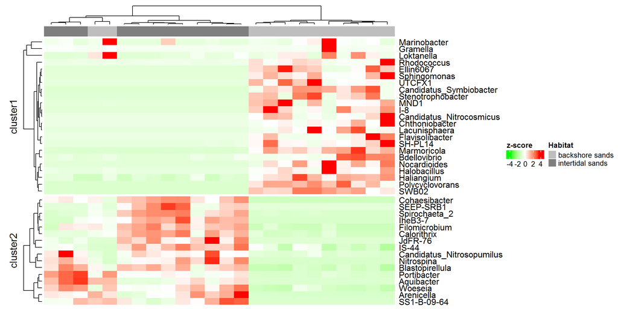

```r
annot_df <- data.frame(Habitat = colnames(genus_ind_s))
col = list(Habitat = c("backshore sands" = "grey", "intertidal sands" = "grey50"))

ha <- HeatmapAnnotation(annot_df, col = col)

col_fun = colorRamp2(c(-3, 0, 3), c("green", "white", "red"))

###Plot
Heatmap(genus_ind_s, col = col_fun, top_annotation = ha, name = "z-score",
        show_row_names = T, show_column_names = F, km = 2,
        clustering_distance_rows = "spearman",
        clustering_distance_columns = "spearman",
        heatmap_legend_param = list(color_bar = "continuous",
                                    legend_direction = "horizontal",
                                    legend_height = unit(2, "cm"),
                                    col = cm, km = 2, raster_quality = 1))
```

## Table 2 and Fig. 5

```r
####################################################################################################
###db-RDA analysis--------------Fig.5
####################################################################################################
set.seed(1234567)

##VIF analysis
sand2017_env2.test = sand2017_env2

vif.sand = vifstep(scale(sand2017_env2.test[,c(1:4,6:8,10:13)]), th = 5)
select.env = c(as.character(vif.sand@results$Variables))
sand2017_env2_sel <- dplyr::select(sand2017_env2.test, select.env)

###PCNM
##distance between sampling sites
sand_geo = read.table("Sand_geo.txt")
sand_geo = sand_geo[match(rownames(sand2017_env2_sel),
                          rownames(sand_geo)), ]
##matrix
sand.lonlat=cbind(sand_geo$log, sand_geo$Lat);

##calculating distances
sand.dists=distm(sand.lonlat, fun=distVincentyEllipsoid);

rownames(sand.dists)=rownames(sand_geo);
colnames(sand.dists)=rownames(sand_geo);

sand.mod.pcnm <- pcnm(sand.dists, dist.ret=TRUE)
sand.dat.pcnm <- as.data.frame(sand.mod.pcnm$vectors)


#####################################Variation partitioning analysis
###Whole communities
E = sand2017_env2_sel
S = sand.dat.pcnm
M = otu_sand

E=data.frame(scale(E))

#model processing
source("ESM_dbRDA_varpart_2way.R") #--call source code with dbRDA model selection and variation partitioning calculations
```

```
##
## Start: dat.comm ~ 1
##
##               Df    AIC      F Pr(>F)
## + EC           1 45.541 7.6889  0.005 **
## + Cr           1 49.059 3.6418  0.005 **
## + Zn           1 50.428 2.2195  0.005 **
## + Available.P  1 49.224 3.4661  0.010 **
## + TN           1 50.922 1.7262  0.090 .
## + TOC          1 51.277 1.3783  0.170
## + Grain.size   1 51.734 0.9372  0.460
## + NH4.N        1 51.757 0.9152  0.460
## + As           1 51.880 0.7982  0.595
## + NO3.N        1 52.057 0.6304  0.825
## + Cu           1 52.055 0.6319  0.840
## ---
## Signif. codes:  0 '***' 0.001 '**' 0.01 '*' 0.05 '.' 0.1 ' ' 1
##
## Step: dat.comm ~ EC
##
##               Df    AIC      F Pr(>F)
## + Zn           1 45.551 1.8155  0.045 *
## + Available.P  1 45.677 1.6965  0.050 *
## + TN           1 45.743 1.6341  0.050 *
## + Cr           1 45.965 1.4259  0.110
## + NH4.N        1 46.192 1.2149  0.210
## + TOC          1 46.199 1.2078  0.230
## + Grain.size   1 46.270 1.1423  0.285
## + As           1 46.312 1.1038  0.330
## + Cu           1 46.604 0.8362  0.665
## + NO3.N        1 46.790 0.6678  0.900
## ---
## Signif. codes:  0 '***' 0.001 '**' 0.01 '*' 0.05 '.' 0.1 ' ' 1
##
## Step: dat.comm ~ EC + Zn
##
##               Df    AIC      F Pr(>F)
## + Available.P  1 45.558 1.7323  0.050 *
## + TN           1 45.861 1.4595  0.090 .
## + Cr           1 45.961 1.3698  0.120
```

[output cut: 136 more lines]

```
## + PCNM2  1 55.351 1.6810  0.075 .
## + PCNM6  1 56.362 0.8692  0.575
## + PCNM4  1 56.397 0.8415  0.585
## ---
## Signif. codes:  0 '***' 0.001 '**' 0.01 '*' 0.05 '.' 0.1 ' ' 1
##
## Step: scale(dat.env) ~ PCNM7 + PCNM9 + PCNM3 + PCNM5 + PCNM1
##
##         Df    AIC      F Pr(>F)
## + PCNM8  1 54.307 1.9305  0.080 .
## + PCNM2  1 54.487 1.7888  0.080 .
## + PCNM6  1 55.623 0.9201  0.395
## + PCNM4  1 55.663 0.8907  0.590
## ---
## Signif. codes:  0 '***' 0.001 '**' 0.01 '*' 0.05 '.' 0.1 ' ' 1
```

```r
#VPA for the whole communities
dat.varpart
```

```
##              predictor.var     adj.R2 Df1 Df2        F N.Perm P.val
## abc           env.AND.pcnm 0.34497836   6  17 3.018891    999 0.001
## ab                     env 0.27816222   3  20 3.954372    999 0.001
## bc                    pcnm 0.23955577   3  20 3.415160    999 0.001
## a                 env|pcnm 0.10542260   3  17 2.072968    999 0.002
## b                     <NA> 0.17273963  NA  NA       NA   <NA>    NA
## c                 pcnm|env 0.06681614   3  17 1.680040    999 0.007
## env.commpcnm envBYcommpcnm 0.14631636   3  20 2.314022    999 0.001
## env              envBYpcnm 0.27616760   5  18 2.755062    999 0.001
##                           vars.env                             vars.pcnm
## abc          EC + Zn + Available.P                 PCNM7 + PCNM9 + PCNM1
## ab           EC + Zn + Available.P                                  <NA>
## bc                            <NA>                 PCNM7 + PCNM9 + PCNM1
## a                             <NA>                                  <NA>
## b                             <NA>                                  <NA>
## c                             <NA>                                  <NA>
## env.commpcnm                  <NA>                 PCNM7 + PCNM9 + PCNM1
## env                           <NA> PCNM7 + PCNM9 + PCNM3 + PCNM5 + PCNM1
```

```r
###db-RDA plot
#### Remove data points with missing metadata
dongshan_sand2.capno <- dongshan_sand2 %>%
  subset_samples(!is.na(EC) &  !is.na(TN) & !is.na(Available.P))

bray_not_na <- phyloseq::distance(physeq = dongshan_sand2.capno, method = "bray")

# CAP ordinate the whole communities
cap_ord <- ordinate(physeq = dongshan_sand2.capno, method = "CAP", distance = bray_not_na,
                    formula = ~ EC + TN + Available.P)

# CAP plot
cap_plot <- plot_ordination(physeq = dongshan_sand2.capno, ordination = cap_ord,
                            color = "Site", axes = c(1,2)) +
  aes(color = Site, shape = Environment) +
  geom_point(aes(colour = Site), alpha = 1, size = 5) +
  geom_point(colour = "white", size = 2) +
  scale_color_manual(name = "Site", values = c("#1919ff","red", "#4daf4a", "#ffae19",
                                               "#a65628", "darkorchid3", "magenta")) +
  scale_shape_manual(values=c(19, 17),
                     breaks = c("backshore sands", "intertidal sands"),
                     labels= c("Supratidal", "Intertidal"))


# Now add the environmental variables as arrows
arrowmat <- vegan::scores(cap_ord, display = "bp")

# Add labels, make a data.frame
arrowdf <- data.frame(labels = rownames(arrowmat), arrowmat)

# Define the arrow aesthetic mapping
arrow_map <- aes(xend = CAP1, yend = CAP2, x = 0, y = 0,
                 shape = NULL, color = NULL, label = labels)

label_map <- aes(x = 1.12 * CAP1, y = 1.12 * CAP2,
                 shape = NULL,  color = NULL, label = labels)

arrowhead = arrow(length = unit(0.015, "npc"))

# Make a new graphic
cap_plot2 = cap_plot + geom_segment(
  mapping = arrow_map, size = 0.5, data = arrowdf,
  color = "black", arrow = arrowhead) +
  geom_text(mapping = label_map,  size = 5,
            data = arrowdf, show.legend = FALSE) +
  theme_bw() +
  theme(axis.title.x = element_text(face="bold", size=12),
        axis.title.y = element_text(face="bold", size=12),
        axis.text.x = element_text(colour = "black", size=10),
        axis.text.y = element_text(colour = "black", size=10),
        legend.title = element_text(size=13.5, face = "bold"),
        legend.text = element_text(size=13.5),
        legend.position="none")


###Generalists
M = t(otu_sand_generalist)

#model processing
source("ESM_dbRDA_varpart_2way.R") #--call source code with dbRDA model selection and variation partitioning calculations
```

```
##
## Start: dat.comm ~ 1
##
##               Df    AIC       F Pr(>F)
## + EC           1 37.041 11.2564  0.005 **
## + Available.P  1 42.384  4.6189  0.005 **
## + Zn           1 43.962  2.9244  0.005 **
## + Cr           1 42.773  4.1905  0.015 *
## + TOC          1 45.319  1.5541  0.140
## + TN           1 45.193  1.6782  0.150
## + Grain.size   1 45.934  0.9589  0.340
## + NH4.N        1 45.947  0.9464  0.445
## + As           1 46.229  0.6782  0.590
## + NO3.N        1 46.303  0.6082  0.685
## + Cu           1 46.418  0.5003  0.855
## ---
## Signif. codes:  0 '***' 0.001 '**' 0.01 '*' 0.05 '.' 0.1 ' ' 1
##
## Step: dat.comm ~ EC
##
##               Df    AIC      F Pr(>F)
## + Available.P  1 37.172 1.7007  0.045 *
## + Zn           1 36.676 2.1743  0.070 .
## + TN           1 37.283 1.5953  0.135
## + NH4.N        1 37.461 1.4288  0.135
## + TOC          1 37.691 1.2147  0.180
## + Grain.size   1 37.595 1.3043  0.210
## + Cr           1 37.648 1.2544  0.235
## + As           1 37.773 1.1386  0.280
## + Cu           1 38.150 0.7943  0.615
## + NO3.N        1 38.374 0.5919  0.880
## ---
## Signif. codes:  0 '***' 0.001 '**' 0.01 '*' 0.05 '.' 0.1 ' ' 1
##
## Step: dat.comm ~ EC + Available.P
##
##              Df    AIC      F Pr(>F)
## + TN          1 37.256 1.6619  0.060 .
## + Zn          1 36.684 2.1842  0.065 .
## + As          1 37.271 1.6480  0.070 .
```

[output cut: 112 more lines]

```
## + PCNM6  1 57.018 0.8214  0.575
## + PCNM4  1 57.050 0.7953  0.675
## ---
## Signif. codes:  0 '***' 0.001 '**' 0.01 '*' 0.05 '.' 0.1 ' ' 1
##
## Step: scale(dat.env) ~ PCNM7 + PCNM3 + PCNM9 + PCNM5
##
##         Df    AIC      F Pr(>F)
## + PCNM1  1 54.888 2.0638  0.065 .
## + PCNM2  1 55.351 1.6810  0.065 .
## + PCNM8  1 55.191 1.8126  0.070 .
## + PCNM6  1 56.362 0.8692  0.565
## + PCNM4  1 56.397 0.8415  0.575
## ---
## Signif. codes:  0 '***' 0.001 '**' 0.01 '*' 0.05 '.' 0.1 ' ' 1
```

```r
###VPA for generalists
dat.varpart
```

```
##              predictor.var    adj.R2 Df1 Df2        F N.Perm P.val
## abc           env.AND.pcnm 0.4107543   5  18 4.206591    999 0.001
## ab                     env 0.3297507   2  21 6.657795    999 0.001
## bc                    pcnm 0.2878148   3  20 4.098323    999 0.001
## a                 env|pcnm 0.1229395   2  18 3.086389    999 0.007
## b                     <NA> 0.2068112  NA  NA       NA   <NA>    NA
## c                 pcnm|env 0.0810036   3  18 1.962290    999 0.008
## env.commpcnm envBYcommpcnm 0.1463164   3  20 2.314022    999 0.001
## env              envBYpcnm 0.2356396   4  19 2.772629    999 0.001
##                      vars.env                     vars.pcnm
## abc          EC + Available.P         PCNM7 + PCNM9 + PCNM1
## ab           EC + Available.P                          <NA>
## bc                       <NA>         PCNM7 + PCNM9 + PCNM1
## a                        <NA>                          <NA>
## b                        <NA>                          <NA>
## c                        <NA>                          <NA>
## env.commpcnm             <NA>         PCNM7 + PCNM9 + PCNM1
## env                      <NA> PCNM7 + PCNM3 + PCNM9 + PCNM5
```

```r
#### Remove data points with missing metadata
sand_qiime_generalist.capno <- sand_qiime_generalist %>%
  subset_samples(!is.na(EC) & !is.na(Zn))

bray_not_na <- phyloseq::distance(physeq = sand_qiime_generalist.capno, method = "bray")

# CAP ordinate all community
cap_ord <- ordinate(physeq = sand_qiime_generalist.capno, method = "CAP", distance = bray_not_na,
                    formula = ~ EC + Zn)

# CAP plot
cap_plot_gen <- plot_ordination(physeq = sand_qiime_generalist.capno, ordination = cap_ord,
                            color = "Site", axes = c(1,2)) +
  aes(color = Site, shape = Environment) +
  geom_point(aes(colour = Site), alpha = 1, size = 5) +
  geom_point(colour = "white", size = 2) +
  scale_color_manual(name = "Site", values = c("#1919ff","red", "#4daf4a", "#ffae19",
                                               "#a65628", "darkorchid3", "magenta")) +
  scale_shape_manual(values=c(19, 17),
                     breaks = c("backshore sands", "intertidal sands"),
                     labels= c("Supratidal", "Intertidal"))


# Now add the environmental variables as arrows
arrowmat <- vegan::scores(cap_ord, display = "bp")

# Add labels, make a data.frame
arrowdf <- data.frame(labels = rownames(arrowmat), arrowmat)

# Define the arrow aesthetic mapping
arrow_map <- aes(xend = CAP1, yend = CAP2, x = 0, y = 0,
                 shape = NULL, color = NULL, label = labels)

label_map <- aes(x = 1.12 * CAP1, y = 1.12 * CAP2,
                 shape = NULL,  color = NULL, label = labels)

arrowhead = arrow(length = unit(0.015, "npc"))

# Make a new graphic
cap_plot2_gen = cap_plot_gen + geom_segment(
  mapping = arrow_map, size = 0.5, data = arrowdf,
  color = "black", arrow = arrowhead) +
  geom_text(mapping = label_map,  size = 5,
            data = arrowdf, show.legend = FALSE) +
  theme_bw() +
  theme(axis.title.x = element_text(face="bold", size=12),
        axis.title.y = element_text(face="bold", size=12),
        axis.text.x = element_text(colour = "black", size=10),
        axis.text.y = element_text(colour = "black", size=10),
        legend.title = element_text(size=13.5, face = "bold"),
        legend.text = element_text(size=13.5),
        legend.position="none")


###Specialists
M = t(otu_sand_specialist)

#model processing
source("ESM_dbRDA_varpart_2way.R") #--call source code with dbRDA model selection and variation partitioning calculations
```

```
##
## Start: dat.comm ~ 1
##
##               Df    AIC      F Pr(>F)
## + EC           1 49.028 6.4032  0.005 **
## + Available.P  1 52.096 2.9950  0.005 **
## + Cr           1 51.512 3.6108  0.010 **
## + TN           1 52.561 2.5153  0.015 *
## + Zn           1 53.202 1.8692  0.015 *
## + TOC          1 53.871 1.2135  0.285
## + Grain.size   1 54.082 1.0102  0.425
## + As           1 54.262 0.8381  0.625
## + NH4.N        1 54.389 0.7177  0.785
## + Cu           1 54.464 0.6463  0.850
## + NO3.N        1 54.727 0.3994  1.000
## ---
## Signif. codes:  0 '***' 0.001 '**' 0.01 '*' 0.05 '.' 0.1 ' ' 1
##
## Step: dat.comm ~ EC
##
##               Df    AIC      F Pr(>F)
## + Zn           1 48.922 1.9259  0.005 **
## + TN           1 48.598 2.2381  0.015 *
## + Available.P  1 49.460 1.4178  0.125
## + Cr           1 49.454 1.4235  0.160
## + Grain.size   1 49.697 1.1979  0.240
## + TOC          1 49.840 1.0663  0.330
## + As           1 49.853 1.0540  0.455
## + NH4.N        1 50.036 0.8863  0.580
## + Cu           1 50.183 0.7525  0.755
## + NO3.N        1 50.542 0.4298  1.000
## ---
## Signif. codes:  0 '***' 0.001 '**' 0.01 '*' 0.05 '.' 0.1 ' ' 1
##
## Step: dat.comm ~ EC + Zn
##
##               Df    AIC      F Pr(>F)
## + TN           1 48.513 2.1120  0.030 *
## + Available.P  1 49.198 1.4899  0.115
## + Cr           1 49.352 1.3521  0.175
```

[output cut: 156 more lines]

```
## + PCNM1  1 54.307 2.1705  0.010 **
## + PCNM2  1 54.821 1.7641  0.100 .
## + PCNM6  1 55.942 0.9080  0.495
## + PCNM4  1 55.981 0.8790  0.605
## ---
## Signif. codes:  0 '***' 0.001 '**' 0.01 '*' 0.05 '.' 0.1 ' ' 1
##
## Step: scale(dat.env) ~ PCNM7 + PCNM3 + PCNM9 + PCNM5 + PCNM8 + PCNM1
##
##         Df    AIC      F Pr(>F)
## + PCNM2  1 53.617 1.8975   0.06 .
## + PCNM6  1 54.894 0.9703   0.43
## + PCNM4  1 54.938 0.9391   0.51
## ---
## Signif. codes:  0 '***' 0.001 '**' 0.01 '*' 0.05 '.' 0.1 ' ' 1
```

```r
###VPA for specialists
dat.varpart
```

```
##              predictor.var     adj.R2 Df1 Df2        F N.Perm P.val
## abc           env.AND.pcnm 0.34983625   7  16 2.765886    999 0.001
## ab                     env 0.26215489   3  20 3.721986    999 0.001
## bc                    pcnm 0.27588985   4  19 3.188974    999 0.001
## a                 env|pcnm 0.07394640   3  16 1.719034    999 0.011
## b                     <NA> 0.18820849  NA  NA       NA   <NA>    NA
## c                 pcnm|env 0.08768136   4  16 1.673049    999 0.002
## env.commpcnm envBYcommpcnm 0.18673416   4  19 2.320259    999 0.001
## env              envBYpcnm 0.31174646   6  17 2.736320    999 0.001
##                  vars.env                                     vars.pcnm
## abc          EC + Zn + TN                 PCNM7 + PCNM1 + PCNM9 + PCNM5
## ab           EC + Zn + TN                                          <NA>
## bc                   <NA>                 PCNM7 + PCNM1 + PCNM9 + PCNM5
## a                    <NA>                                          <NA>
## b                    <NA>                                          <NA>
## c                    <NA>                                          <NA>
## env.commpcnm         <NA>                 PCNM7 + PCNM1 + PCNM9 + PCNM5
## env                  <NA> PCNM7 + PCNM3 + PCNM9 + PCNM5 + PCNM8 + PCNM1
```

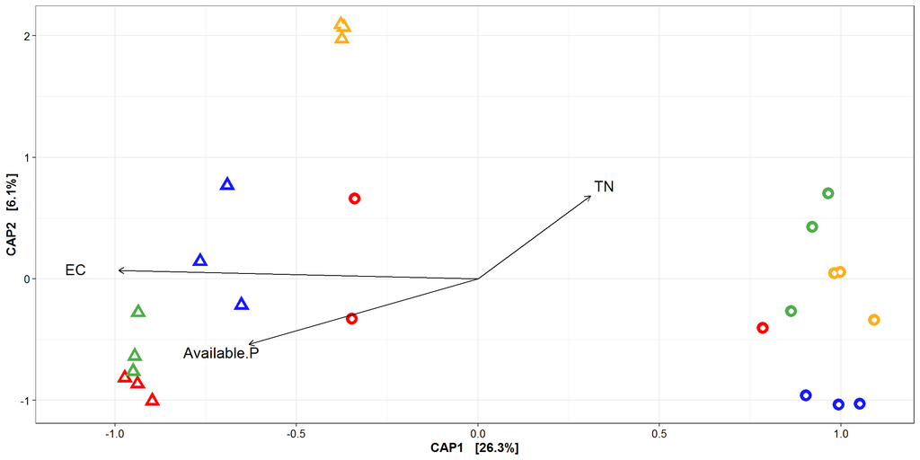

```r
#### Remove data points with missing metadata
sand_qiime_specialist.capno <- sand_qiime_specialist %>%
  subset_samples(!is.na(EC) & !is.na(TN) & !is.na(Zn))

bray_not_na <- phyloseq::distance(physeq = sand_qiime_specialist.capno, method = "bray")

# CAP ordinate all community
cap_ord <- ordinate(physeq = sand_qiime_specialist.capno, method = "CAP", distance = bray_not_na,
                    formula = ~ EC + TN + Zn)

# CAP plot
cap_plot_spe <- plot_ordination(physeq = sand_qiime_specialist.capno, ordination = cap_ord,
                            color = "Site", axes = c(1,2)) +
  aes(color = Site, shape = Environment) +
  geom_point(aes(colour = Site), alpha = 1, size = 5) +
  geom_point(colour = "white", size = 2) +
  scale_color_manual(name = "Site", values = c("#1919ff","red", "#4daf4a", "#ffae19",
                                               "#a65628", "darkorchid3", "magenta")) +
  scale_shape_manual(values=c(19, 17),
                     breaks = c("backshore sands", "intertidal sands"),
                     labels= c("Supratidal", "Intertidal"))


# Now add the environmental variables as arrows
arrowmat <- vegan::scores(cap_ord, display = "bp")

# Add labels, make a data.frame
arrowdf <- data.frame(labels = rownames(arrowmat), arrowmat)

# Define the arrow aesthetic mapping
arrow_map <- aes(xend = CAP1, yend = CAP2, x = 0, y = 0,
                 shape = NULL, color = NULL, label = labels)

label_map <- aes(x = 1.12 * CAP1, y = 1.12 * CAP2,
                 shape = NULL,  color = NULL, label = labels)

arrowhead = arrow(length = unit(0.015, "npc"))

# Make a new graphic
cap_plot2_spe = cap_plot_spe + geom_segment(
  mapping = arrow_map, size = 0.5, data = arrowdf,
  color = "black", arrow = arrowhead) +
  geom_text(mapping = label_map,  size = 5,
            data = arrowdf, show.legend = FALSE) +
  theme_bw() +
  theme(axis.title.x = element_text(face="bold", size=12),
        axis.title.y = element_text(face="bold", size=12),
        axis.text.x = element_text(colour = "black", size=10),
        axis.text.y = element_text(colour = "black", size=10),
        legend.title = element_text(size=13.5, face = "bold"),
        legend.text = element_text(size=13.5),
        legend.position="right")

cap_plot2
```

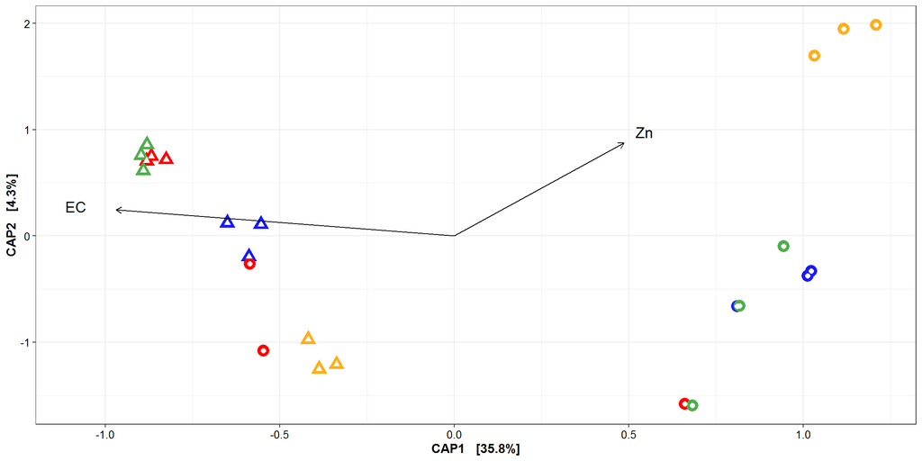

```r
cap_plot2_gen
```

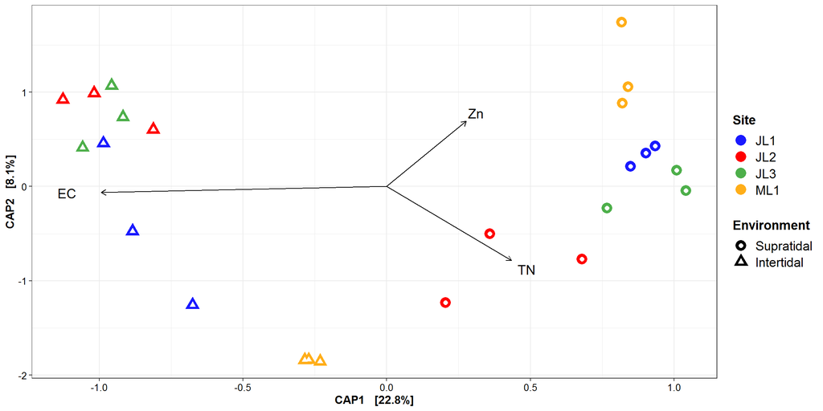

```r
cap_plot2_spe
```

## Fig. 6

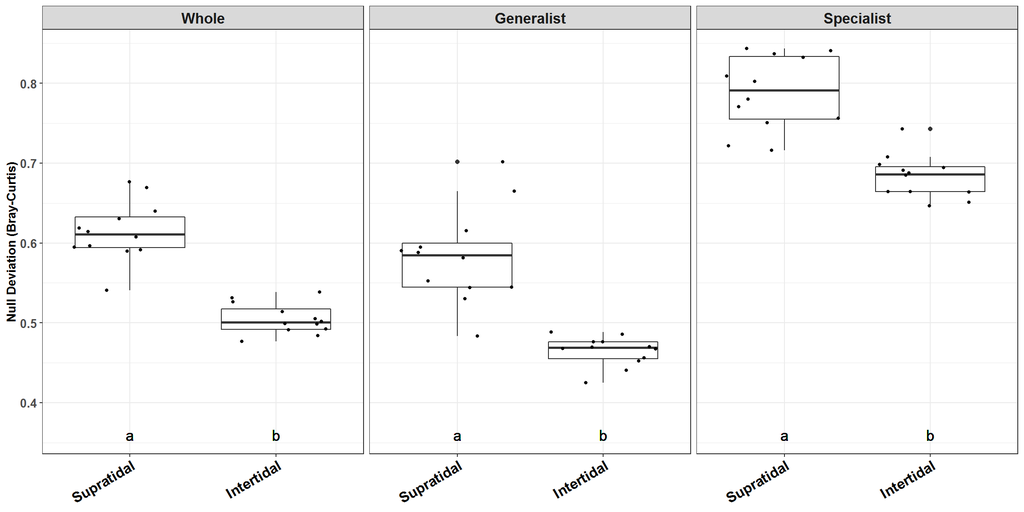

```r
#######################################################################################################
####Beta null model--------------Fig.6
#######################################################################################################
###The beta-diversity null model analysis was performed by using the R code from Tucker et al., (2016)
betanull_bacwhole.out = read.table("bnullout_sand_whole.txt", header=TRUE, sep="\t")
betanull_bacgen.out = read.table("bnullout_sand_gen.txt", header=TRUE, sep="\t")
betanull_bacspe.out = read.table("bnullout_sand_spe.txt", header=TRUE, sep="\t")

betanull_bacwhole.out = merge(betanull_bacwhole.out[,c(1:2)], sand2017_env[,c(1,5,7)],
                          by = 0, all = T)
betanull_bacgen.out = merge(betanull_bacgen.out[,c(1:2)], sand2017_env[,c(1,5,7)],
                              by = 0, all = T)
betanull_bacspe.out = merge(betanull_bacspe.out[,c(1:2)], sand2017_env[,c(1,5,7)],
                              by = 0, all = T)

betanull_bacwhole.out$group=paste("Whole")
betanull_bacgen.out$group=paste("Generalist")
betanull_bacspe.out$group=paste("Specialist")

###Kruskal-Wallis test
betanull_whole_KW <- kruskalmc(betanull_bacwhole.out$BRAY_AbundanceNullDeviation,
                                      betanull_bacwhole.out$Environment)
betanull_bacgen_KW <- kruskalmc(betanull_bacgen.out$BRAY_AbundanceNullDeviation,
                               betanull_bacgen.out$Environment)
betanull_bacspe_KW <- kruskalmc(betanull_bacspe.out$BRAY_AbundanceNullDeviation,
                                betanull_bacspe.out$Environment)


### Time to figure out letters to represent significance in a plot
whole_test <- betanull_whole_KW$dif.com$difference # select logical vector
names(whole_test) <- row.names(betanull_whole_KW$dif.com) # add comparison names
# create a list with "homogenous groups" coded by letter
whole_letters <- multcompLetters(whole_test, compare="<", threshold=0.05,
                                Letters=c(letters, LETTERS, "."), reversed = FALSE)

###  Extract the values from the multcompLetters object
whole_sigs_dataframe <-  data.frame(as.vector(names(whole_letters$Letters)), as.vector(whole_letters$Letters))
colnames(whole_sigs_dataframe) <- c("Environment", "siglabel")
betanull_bacwhole.out <- merge(betanull_bacwhole.out, whole_sigs_dataframe, by = "Environment")


### Time to figure out letters to represent significance in a plot
gen_test <- betanull_bacgen_KW$dif.com$difference # select logical vector
names(gen_test) <- row.names(betanull_bacgen_KW$dif.com) # add comparison names
# create a list with "homogenous groups" coded by letter
gen_letters <- multcompLetters(gen_test, compare="<", threshold=0.05,
                                 Letters=c(letters, LETTERS, "."), reversed = FALSE)

###  Extract the values from the multcompLetters object
gen_sigs_dataframe <-  data.frame(as.vector(names(gen_letters$Letters)), as.vector(gen_letters$Letters))
colnames(gen_sigs_dataframe) <- c("Environment", "siglabel")
betanull_bacgen.out <- merge(betanull_bacgen.out, gen_sigs_dataframe, by = "Environment")


### Time to figure out letters to represent significance in a plot
spe_test <- betanull_bacspe_KW$dif.com$difference # select logical vector
names(spe_test) <- row.names(betanull_bacspe_KW$dif.com) # add comparison names
# create a list with "homospeous groups" coded by letter
spe_letters <- multcompLetters(spe_test, compare="<", threshold=0.05,
                               Letters=c(letters, LETTERS, "."), reversed = FALSE)

###  Extract the values from the multcompLetters object
spe_sigs_dataframe <-  data.frame(as.vector(names(spe_letters$Letters)), as.vector(spe_letters$Letters))
colnames(spe_sigs_dataframe) <- c("Environment", "siglabel")
betanull_bacspe.out <- merge(betanull_bacspe.out, spe_sigs_dataframe, by = "Environment")


###
betanull_bac.out = rbind(betanull_bacwhole.out,
                         betanull_bacgen.out, betanull_bacspe.out)

levels(betanull_bac.out$Environment) <- c("Supratidal", "Intertidal")

betanull_bac.out$group = factor(betanull_bac.out$group, c("Whole", "Generalist", "Specialist"))


##Box_plot
bnull_plot <- ggplot(data=betanull_bac.out, aes(x=Environment, y=BRAY_AbundanceNullDeviation))+
  geom_boxplot()+
  geom_jitter(aes(y=BRAY_AbundanceNullDeviation,cex=1), size = 1)+
  geom_text(data = betanull_bac.out, aes(label = siglabel, x = Environment, y = 0.36), size =4.5)+
  scale_size(guide=FALSE)+
  scale_y_continuous(name="Null Deviation (Bray-Curtis)")+
  facet_grid(~group) +
  theme_bw(base_size=10)+
  theme(axis.text.x = element_text(angle=30, vjust=1, hjust = 1, colour = "black", face = "bold", size = 12),
        axis.title.x = element_blank(),
        axis.text.y = element_text(face="bold", size = 10),
        axis.title.y = element_text(face="bold", size=10),
        strip.text.x = element_text(size = 12.5, face="bold"),
        legend.position = "none")

bnull_plot
```

## Fig. 7

```r
####################################################################################################
####NCM Neutral model--------------Fig.7
###################################################################################################
source("Neutral_model_ISME2016.R")
set.seed(1234567)

###Supratidal communities
dongshan_sand2_back <- subset_samples(dongshan_sand2, Environment == "backshore sands")
dongshan_sand2_back <- prune_taxa(taxa_sums(dongshan_sand2_back) > 0, dongshan_sand2_back)
dongshan_sand2_back
```

```
## phyloseq-class experiment-level object
## otu_table()   OTU Table:         [ 6660 taxa and 12 samples ]
## sample_data() Sample Data:       [ 12 samples by 24 sample variables ]
## tax_table()   Taxonomy Table:    [ 6660 taxa by 6 taxonomic ranks ]
```

```r
otu_sand2_back = as.data.frame(otu_table(dongshan_sand2_back))

mod_w_back = sncm.fit(otu_sand2_back)
mod1_w_back = sncm.fit(otu_sand2_back,stats = F)

##Identify above, below and netural OTUs
addf = function(freq, pred.upr, pred.lwr) {
  if(freq > pred.upr){
    model = "above"
  }
  else if(freq < pred.lwr){
    model = "below"
  }
  else if(pred.upr >= freq & freq >= pred.lwr){
    model = "neutral"
  }
  return(model)
}

mod1_w_back$model = mapply(addf, mod1_w_back$freq, mod1_w_back$pred.upr, mod1_w_back$pred.lwr)
length(which(mod1_w_back$model == "above"))
```

```
## [1] 86
```

```r
length(which(mod1_w_back$model == "below"))
```

```
## [1] 157
```

```r
length(which(mod1_w_back$model == "neutral"))
```

```
## [1] 6417
```

```r
mod1_w_back$model <- factor(mod1_w_back$model,
                            levels = c("above", "neutral", "below"))

#plot neuModel
p_neuM_back=ggplot(mod1_w_back, aes(x=log10(p), y=freq, color = model))+
  geom_point(shape=19, alpha=0.7, size=2.5)+
  geom_line(aes(x=log10(p), y=freq.pred),
            color="blue",linetype="solid",size=1)+
  geom_line(aes(x=log10(p), y=pred.lwr),
            color="blue",linetype="dashed",size=1)+
  geom_line(aes(x=log10(p), y=pred.upr),
            color="blue",linetype="dashed",size=1)+
  scale_colour_manual(name="OTUs",
                      values=c("#E41A1C", "#999999", "#33A02C"),
                      breaks=c("above", "neutral", "below"),
                      labels=c("Over-represented", "Neutrally-distributed", "Under-represented"))+
  xlab("Log10 (Mean Relative abundance)") + ylab("Occurance frequency")+
  theme_bw() +
  theme(axis.title.x = element_text(face="bold", size=11),
        axis.title.y = element_text(face="bold", size=11),
        axis.text.x = element_text(colour = "black", size=10),
        axis.text.y = element_text(colour = "black", size=10),
        legend.title = element_text(size=11.5, face = "bold"),
        legend.text = element_text(size=11.5),
        legend.position="none")

lb1 <- expression(paste(R^2, " = 0.224"))
lb2 <- expression(paste(m, " = 0.013"))
p_neuM_back1 = p_neuM_back + annotate("text", x = -4.8, y=0.98, size=5.5, label=lb1,
                                  fontface="bold", color="black",
                                  parse=TRUE) +
  annotate("text", x = -4.8, y=0.9, size=5.5, label=lb2,
           fontface="bold", color="black",
           parse=TRUE)


###Intertidal communities
dongshan_sand2_inter <- subset_samples(dongshan_sand2, Environment == "intertidal sands")
dongshan_sand2_inter <- prune_taxa(taxa_sums(dongshan_sand2_inter) > 0, dongshan_sand2_inter)
dongshan_sand2_inter
```

```
## phyloseq-class experiment-level object
## otu_table()   OTU Table:         [ 4506 taxa and 12 samples ]
## sample_data() Sample Data:       [ 12 samples by 24 sample variables ]
## tax_table()   Taxonomy Table:    [ 4506 taxa by 6 taxonomic ranks ]
```

```r
otu_sand2_inter = as.data.frame(otu_table(dongshan_sand2_inter))

mod_w_inter = sncm.fit(otu_sand2_inter)
mod1_w_inter = sncm.fit(otu_sand2_inter,stats = F)

##Identify above, below and netural OTUs
mod1_w_inter$model = mapply(addf, mod1_w_inter$freq, mod1_w_inter$pred.upr, mod1_w_inter$pred.lwr)
length(which(mod1_w_inter$model == "above"))
```

```
## [1] 153
```

```r
length(which(mod1_w_inter$model == "below"))
```

```
## [1] 144
```

```r
length(which(mod1_w_inter$model == "neutral"))
```

```
## [1] 4209
```

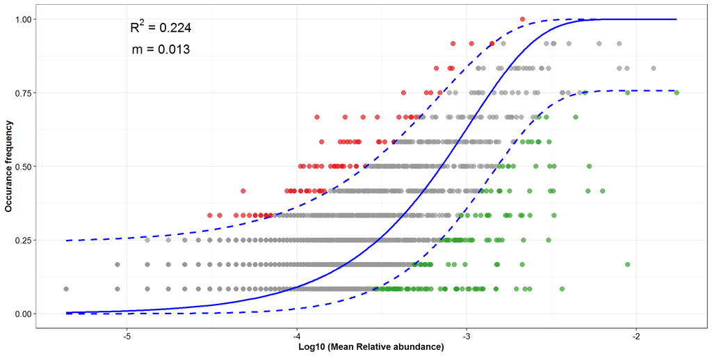

```r
mod1_w_inter$model <- factor(mod1_w_inter$model,
                             levels = c("above", "neutral", "below"))

#plot neuModel
p_neuM_inter=ggplot(mod1_w_inter, aes(x=log10(p), y=freq, color = model))+
  geom_point(shape=19, alpha=0.7, size=2.5)+
  geom_line(aes(x=log10(p), y=freq.pred),
            color="blue",linetype="solid",size=1)+
  geom_line(aes(x=log10(p), y=pred.lwr),
            color="blue",linetype="dashed",size=1)+
  geom_line(aes(x=log10(p), y=pred.upr),
            color="blue",linetype="dashed",size=1)+
  scale_colour_manual(name="OTUs",
                      values=c("#E41A1C", "#999999", "#33A02C"),
                      breaks=c("above", "neutral", "below"),
                      labels=c("Over-represented", "Neutrally-distributed", "Under-represented"))+
  xlab("Log10 (Mean Relative abundance)") + ylab("Occurance frequency")+
  theme_bw()+
  theme(axis.title.x = element_text(face="bold", size=11),
        axis.title.y = element_text(face="bold", size=11),
        axis.text.x = element_text(colour = "black", size=10),
        axis.text.y = element_text(colour = "black", size=10),
        legend.title = element_text(size=12.5, face = "bold"),
        legend.text = element_text(size=12.5),
        legend.position="none")

lb1 <- expression(paste(R^2, " = 0.671"))
lb2 <- expression(paste(m, " = 0.028"))
p_neuM_inter1 = p_neuM_inter + annotate("text", x = -4.8, y=0.98, size=5.5, label=lb1,
                                      fontface="bold", color="black",
                                      parse=TRUE) +
  annotate("text", x = -4.8, y=0.9, size=5.5, label=lb2,
           fontface="bold", color="black",
           parse=TRUE)


#########################################################################################################
###Percentages of Generalists and Specialists in Neutral Model
#########################################################################################################
mod1_w_inter.gen = subset(mod1_w_inter, rownames(mod1_w_inter) %in% sand_generalist)
mod1_w_inter.spe = subset(mod1_w_inter, rownames(mod1_w_inter) %in% sand_specialist)

mod1_w_back.gen = subset(mod1_w_back, rownames(mod1_w_back) %in% sand_generalist)
mod1_w_back.spe = subset(mod1_w_back, rownames(mod1_w_back) %in% sand_specialist)

#####
inter.gen <- c(length(which(mod1_w_inter.gen$model == "above")),
               length(which(mod1_w_inter.gen$model == "below")),
               length(which(mod1_w_inter.gen$model == "neutral")))

inter.spe <- c(length(which(mod1_w_inter.spe$model == "above")),
               length(which(mod1_w_inter.spe$model == "below")),
               length(which(mod1_w_inter.spe$model == "neutral")))

back.gen <- c(length(which(mod1_w_back.gen$model == "above")),
               length(which(mod1_w_back.gen$model == "below")),
               length(which(mod1_w_back.gen$model == "neutral")))

back.spe <- c(length(which(mod1_w_back.spe$model == "above")),
               length(which(mod1_w_back.spe$model == "below")),
               length(which(mod1_w_back.spe$model == "neutral")))

# Join the variables to create a data frame
mod_w_all <- data.frame(inter.gen, inter.spe, back.gen, back.spe)
mod_w_all$model = c("above", "below","neutral")
mod_w_all_long = melt(mod_w_all, id=c("model"), measure.vars=(colnames(mod_w_all)[1:4]))
mod_w_all_long$group = mod_w_all_long$variable

levels(mod_w_all_long$variable) <- c("Intertidal", "Intertidal", "Supratidal", "Supratidal")
levels(mod_w_all_long$group) <- c("Generalist", "Specialist", "Generalist", "Specialist")

mod_w_all_long$model <- factor(mod_w_all_long$model,
                              levels = c("above", "neutral", "below"))

mod_w_all_long$variable <- factor(mod_w_all_long$variable,
                               levels = c("Supratidal", "Intertidal"))

###
p_neuM_bar.all = ggplot(mod_w_all_long, aes(x=variable, y=value, fill = model)) +
  geom_bar(stat="identity", position=position_dodge()) +
  geom_text(aes(x=variable, label=value, y = value+5), position = position_dodge(width = 1))+
  ylab("ASV richness") +
  scale_fill_manual(name="OTUs",
                    values=c("#E41A1C", "#999999", "#33A02C"),
                    breaks=c("above", "neutral", "below"),
                    labels=c("Over-represented", "Neutrally-distributed", "Under-represented"))+
  facet_wrap(~group, scales="free_y") +
  theme_bw(base_size=10)+
  theme(axis.text.x = element_text(angle=30, vjust=1, hjust = 1, colour = "black", face = "bold", size = 12),
        axis.title.x = element_blank(),
        axis.text.y = element_text(face="bold", size = 11),
        axis.title.y = element_text(face="bold", size=12),
        strip.text.x = element_text(size = 12.5, face="bold"),
        legend.title = element_text(size=12.5, face = "bold"),
        legend.text = element_text(size=12.5),
        legend.position = "right")


p_neuM_back1
```

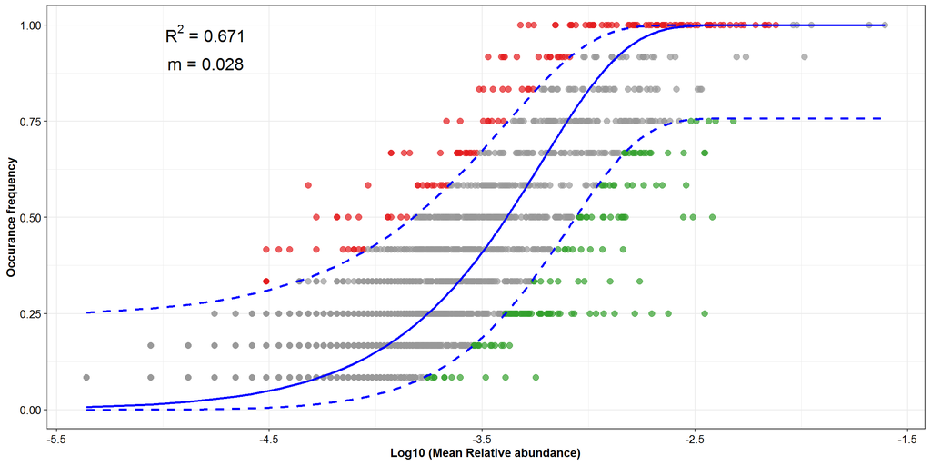

```r
p_neuM_inter1
```

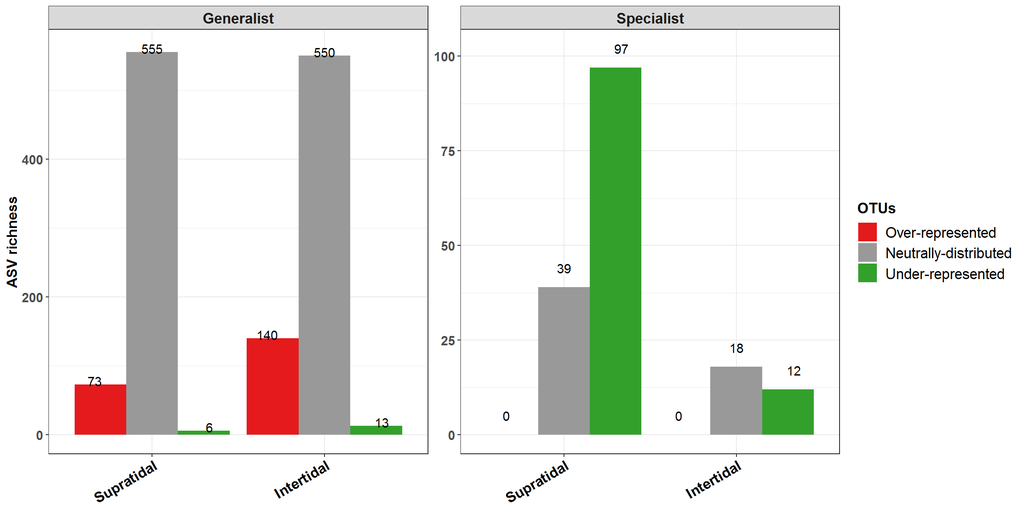

```r
p_neuM_bar.all
```

```r
installed.packages()[names(sessionInfo()$otherPkgs), "Version"]
```

```
##                Hmisc              Formula             survival
##              "4.1-1"              "1.2-3"           "2.44-1.1"
##           minpack.lm               ggpubr             magrittr
##              "1.2-1"                "0.2"                "1.5"
##            geosphere             circlize       ComplexHeatmap
##              "1.5-7"              "0.4.5"             "1.20.0"
##            EcolUtils        ggVennDiagram                 usdm
##                "0.1"                "0.3"             "1.1-18"
##               raster                   sp         RColorBrewer
##              "2.8-4"              "1.3-1"              "1.1-2"
##               labdsv              cluster                 MASS
##              "1.8-0"              "2.0.8"           "7.3-51.4"
##                 mgcv                 nlme            BiocStyle
##             "1.8-28"            "3.1-139"             "2.10.0"
##              cowplot               pander         multcompView
##              "0.9.3"              "0.6.3"              "0.1-7"
##             pgirmess               gtable               scales
##              "1.6.9"              "0.3.0"              "1.0.0"
##              sciplot                tidyr                dplyr
##              "1.1-1"              "0.8.3"              "0.8.3"
##               DESeq2 SummarizedExperiment         DelayedArray
##             "1.22.1"             "1.12.0"              "0.8.0"
##         BiocParallel          matrixStats              Biobase
##             "1.16.2"             "0.54.0"             "2.42.0"
##        GenomicRanges         GenomeInfoDb              IRanges
##             "1.34.0"             "1.18.1"             "2.16.0"
##            S4Vectors         BiocGenerics           data.table
##             "0.20.1"             "0.28.0"             "1.11.8"
##             reshape2                 plyr                vegan
##              "1.4.3"              "1.8.4"              "2.5-3"
##              lattice              permute                 biom
##            "0.20-38"              "0.9-4"             "0.3.12"
##                  ape              ggplot2             phyloseq
##                "5.2"              "3.2.0"             "1.28.0"
```